# INN_Hotel

```python
# Libraries to help with reading and manipulating data
import pandas as pd
import numpy as np

# libaries to help with data visualization
import matplotlib.pyplot as plt
import seaborn as sns

# Removes the limit for the number of displayed columns
pd.set_option("display.max_columns", None)
# Sets the limit for the number of displayed rows
pd.set_option("display.max_rows", 200)
# setting the precision of floating numbers to 5 decimal points
pd.set_option("display.float_format", lambda x: "%.5f" % x)

# Library to split data
from sklearn.model_selection import train_test_split

# To build model for prediction
import statsmodels.stats.api as sms
from statsmodels.stats.outliers_influence import variance_inflation_factor
import statsmodels.api as sm
from statsmodels.tools.tools import add_constant
from sklearn.tree import DecisionTreeClassifier
from sklearn import tree

# To tune different models
from sklearn.model_selection import GridSearchCV


# To get diferent metric scores
from sklearn.metrics import (
    f1_score,
    accuracy_score,
    recall_score,
    precision_score,
    confusion_matrix,
    roc_auc_score,
    precision_recall_curve,
    roc_curve,
    make_scorer,
)

import warnings
warnings.filterwarnings("ignore")

from statsmodels.tools.sm_exceptions import ConvergenceWarning
warnings.simplefilter("ignore", ConvergenceWarning)
```

```python
import os
print(os.listdir())
```

```
['Untitled.ipynb', 'INN_Hotel.ipynb', '.ipynb_checkpoints', 'venv']
```

```python
# For Downloads
hotel = pd.read_csv('/Users/ClementQuagraine/Downloads/INNHotelsGroup.csv')
```

```python
# copying data to another variable to avoid any changes to original data
data = hotel.copy()
```

```python
# Complete code
data.head()
```

|  | Booking_ID | no_of_adults | no_of_children | no_of_weekend_nights | no_of_week_nights | type_of_meal_plan | required_car_parking_space | room_type_reserved | lead_time | arrival_year | arrival_month | arrival_date | market_segment_type | repeated_guest | no_of_previous_cancellations | no_of_previous_bookings_not_canceled | avg_price_per_room | no_of_special_requests | booking_status |
| --- | --- | --- | --- | --- | --- | --- | --- | --- | --- | --- | --- | --- | --- | --- | --- | --- | --- | --- | --- |
| 0 | INN00001 | 2 | 0 | 1 | 2 | Meal Plan 1 | 0 | Room_Type 1 | 224 | 2017 | 10 | 2 | Offline | 0 | 0 | 0 | 65.00000 | 0 | Not_Canceled |
| 1 | INN00002 | 2 | 0 | 2 | 3 | Not Selected | 0 | Room_Type 1 | 5 | 2018 | 11 | 6 | Online | 0 | 0 | 0 | 106.68000 | 1 | Not_Canceled |
| 2 | INN00003 | 1 | 0 | 2 | 1 | Meal Plan 1 | 0 | Room_Type 1 | 1 | 2018 | 2 | 28 | Online | 0 | 0 | 0 | 60.00000 | 0 | Canceled |
| 3 | INN00004 | 2 | 0 | 0 | 2 | Meal Plan 1 | 0 | Room_Type 1 | 211 | 2018 | 5 | 20 | Online | 0 | 0 | 0 | 100.00000 | 0 | Canceled |
| 4 | INN00005 | 2 | 0 | 1 | 1 | Not Selected | 0 | Room_Type 1 | 48 | 2018 | 4 | 11 | Online | 0 | 0 | 0 | 94.50000 | 0 | Canceled |

```python
# Complete code
data.tail()
```

|  | Booking_ID | no_of_adults | no_of_children | no_of_weekend_nights | no_of_week_nights | type_of_meal_plan | required_car_parking_space | room_type_reserved | lead_time | arrival_year | arrival_month | arrival_date | market_segment_type | repeated_guest | no_of_previous_cancellations | no_of_previous_bookings_not_canceled | avg_price_per_room | no_of_special_requests | booking_status |
| --- | --- | --- | --- | --- | --- | --- | --- | --- | --- | --- | --- | --- | --- | --- | --- | --- | --- | --- | --- |
| 36270 | INN36271 | 3 | 0 | 2 | 6 | Meal Plan 1 | 0 | Room_Type 4 | 85 | 2018 | 8 | 3 | Online | 0 | 0 | 0 | 167.80000 | 1 | Not_Canceled |
| 36271 | INN36272 | 2 | 0 | 1 | 3 | Meal Plan 1 | 0 | Room_Type 1 | 228 | 2018 | 10 | 17 | Online | 0 | 0 | 0 | 90.95000 | 2 | Canceled |
| 36272 | INN36273 | 2 | 0 | 2 | 6 | Meal Plan 1 | 0 | Room_Type 1 | 148 | 2018 | 7 | 1 | Online | 0 | 0 | 0 | 98.39000 | 2 | Not_Canceled |
| 36273 | INN36274 | 2 | 0 | 0 | 3 | Not Selected | 0 | Room_Type 1 | 63 | 2018 | 4 | 21 | Online | 0 | 0 | 0 | 94.50000 | 0 | Canceled |
| 36274 | INN36275 | 2 | 0 | 1 | 2 | Meal Plan 1 | 0 | Room_Type 1 | 207 | 2018 | 12 | 30 | Offline | 0 | 0 | 0 | 161.67000 | 0 | Not_Canceled |

#### By observing the last five rows of the dataset (data.tail()), we can see that for the :

##### Booking Status: There's a mix of both 'Not_Canceled' and 'Canceled' bookings among the last few entries. This gives an indication of the presence of both successful and unsuccessful bookings in the dataset.

##### Guest Demographics: The number of adults varied between 2 and 3, with 0 children for all these entries.

##### Stay Duration: The number of weekend nights ranged from 0 to 2, and weeknights from 2 to 6.

##### Meal Plans: 'Meal Plan 1' and 'Not Selected' are present as meal plan types.

##### Car Parking: No car parking space was required for any of these last five bookings.

##### Room Types: Both 'Room_Type 1' and 'Room_Type 4' cab be observed.

##### Lead Time: Lead times can be seen to vary significantly, from 63 days to 228 days, showing a range of booking habits from relatively short to very long advance bookings.

##### Arrivals: All shown arrivals are in 2018, across different months (April, July, August, October, December).

##### Market Segment: Bookings can be seen to come from both 'Online' and 'Offline' market segments.

##### Previous Activity: For these specific rows, you can see that there are no repeated guests, previous cancellations, or previous bookings that were not canceled, suggesting these could be first-time bookings or bookings by guests without a recent history of these specific activities.

##### Average Price: The average price per room can be seen to vary considerably, from approximately 90.95 to 167.80.

## Understand the shape of the dataset

```python
data.shape
```

```
(36275, 19)
```

##### The dataset has 36275 rows and 19 columns.

## Check the data types of the columns for the dataset

```python
data.info()
```

```
<class 'pandas.core.frame.DataFrame'>
RangeIndex: 36275 entries, 0 to 36274
Data columns (total 19 columns):
 #   Column                                Non-Null Count  Dtype
---  ------                                --------------  -----
 0   Booking_ID                            36275 non-null  object
 1   no_of_adults                          36275 non-null  int64
 2   no_of_children                        36275 non-null  int64
 3   no_of_weekend_nights                  36275 non-null  int64
 4   no_of_week_nights                     36275 non-null  int64
 5   type_of_meal_plan                     36275 non-null  object
 6   required_car_parking_space            36275 non-null  int64
 7   room_type_reserved                    36275 non-null  object
 8   lead_time                             36275 non-null  int64
 9   arrival_year                          36275 non-null  int64
 10  arrival_month                         36275 non-null  int64
 11  arrival_date                          36275 non-null  int64
 12  market_segment_type                   36275 non-null  object
 13  repeated_guest                        36275 non-null  int64
 14  no_of_previous_cancellations          36275 non-null  int64
 15  no_of_previous_bookings_not_canceled  36275 non-null  int64
 16  avg_price_per_room                    36275 non-null  float64
 17  no_of_special_requests                36275 non-null  int64
 18  booking_status                        36275 non-null  object
dtypes: float64(1), int64(13), object(5)
memory usage: 5.3+ MB
```

#### From the data.info() output, we can make the following observations:

##### The data types are distributed as follows:

##### float64: 1 column (avg_price_per_room).

```python
# checking for null values
data.isnull().sum()
```

```
Booking_ID                              0
no_of_adults                            0
no_of_children                          0
no_of_weekend_nights                    0
no_of_week_nights                       0
type_of_meal_plan                       0
required_car_parking_space              0
room_type_reserved                      0
lead_time                               0
arrival_year                            0
arrival_month                           0
arrival_date                            0
market_segment_type                     0
repeated_guest                          0
no_of_previous_cancellations            0
no_of_previous_bookings_not_canceled    0
avg_price_per_room                      0
no_of_special_requests                  0
booking_status                          0
dtype: int64
```

##### The dataset contains 36,275 entries across 19 columns.All columns have 36,275 non-null entries, indicating that there are no missing values in any of the columns.

```python
data.duplicated().sum()
```

```
np.int64(0)
```

##### There are no duplicate values in the data.

## Let's drop the Booking_ID column first before we proceed forward.

```python
# Complete code
data = data.drop(columns=['Booking_ID'])
```

```python
data.head()
```

|  | no_of_adults | no_of_children | no_of_weekend_nights | no_of_week_nights | type_of_meal_plan | required_car_parking_space | room_type_reserved | lead_time | arrival_year | arrival_month | arrival_date | market_segment_type | repeated_guest | no_of_previous_cancellations | no_of_previous_bookings_not_canceled | avg_price_per_room | no_of_special_requests | booking_status |
| --- | --- | --- | --- | --- | --- | --- | --- | --- | --- | --- | --- | --- | --- | --- | --- | --- | --- | --- |
| 0 | 2 | 0 | 1 | 2 | Meal Plan 1 | 0 | Room_Type 1 | 224 | 2017 | 10 | 2 | Offline | 0 | 0 | 0 | 65.00000 | 0 | Not_Canceled |
| 1 | 2 | 0 | 2 | 3 | Not Selected | 0 | Room_Type 1 | 5 | 2018 | 11 | 6 | Online | 0 | 0 | 0 | 106.68000 | 1 | Not_Canceled |
| 2 | 1 | 0 | 2 | 1 | Meal Plan 1 | 0 | Room_Type 1 | 1 | 2018 | 2 | 28 | Online | 0 | 0 | 0 | 60.00000 | 0 | Canceled |
| 3 | 2 | 0 | 0 | 2 | Meal Plan 1 | 0 | Room_Type 1 | 211 | 2018 | 5 | 20 | Online | 0 | 0 | 0 | 100.00000 | 0 | Canceled |
| 4 | 2 | 0 | 1 | 1 | Not Selected | 0 | Room_Type 1 | 48 | 2018 | 4 | 11 | Online | 0 | 0 | 0 | 94.50000 | 0 | Canceled |

## Exploratory Data Analysis

#### Let's check the statistical summary of the data.

```python
# Complete code
data.describe().T
```

|  | count | mean | std | min | 25% | 50% | 75% | max |
| --- | --- | --- | --- | --- | --- | --- | --- | --- |
| no_of_adults | 36275.00000 | 1.84496 | 0.51871 | 0.00000 | 2.00000 | 2.00000 | 2.00000 | 4.00000 |
| no_of_children | 36275.00000 | 0.10528 | 0.40265 | 0.00000 | 0.00000 | 0.00000 | 0.00000 | 10.00000 |
| no_of_weekend_nights | 36275.00000 | 0.81072 | 0.87064 | 0.00000 | 0.00000 | 1.00000 | 2.00000 | 7.00000 |
| no_of_week_nights | 36275.00000 | 2.20430 | 1.41090 | 0.00000 | 1.00000 | 2.00000 | 3.00000 | 17.00000 |
| required_car_parking_space | 36275.00000 | 0.03099 | 0.17328 | 0.00000 | 0.00000 | 0.00000 | 0.00000 | 1.00000 |
| lead_time | 36275.00000 | 85.23256 | 85.93082 | 0.00000 | 17.00000 | 57.00000 | 126.00000 | 443.00000 |
| arrival_year | 36275.00000 | 2017.82043 | 0.38384 | 2017.00000 | 2018.00000 | 2018.00000 | 2018.00000 | 2018.00000 |
| arrival_month | 36275.00000 | 7.42365 | 3.06989 | 1.00000 | 5.00000 | 8.00000 | 10.00000 | 12.00000 |
| arrival_date | 36275.00000 | 15.59700 | 8.74045 | 1.00000 | 8.00000 | 16.00000 | 23.00000 | 31.00000 |
| repeated_guest | 36275.00000 | 0.02564 | 0.15805 | 0.00000 | 0.00000 | 0.00000 | 0.00000 | 1.00000 |
| no_of_previous_cancellations | 36275.00000 | 0.02335 | 0.36833 | 0.00000 | 0.00000 | 0.00000 | 0.00000 | 13.00000 |
| no_of_previous_bookings_not_canceled | 36275.00000 | 0.15341 | 1.75417 | 0.00000 | 0.00000 | 0.00000 | 0.00000 | 58.00000 |
| avg_price_per_room | 36275.00000 | 103.42354 | 35.08942 | 0.00000 | 80.30000 | 99.45000 | 120.00000 | 540.00000 |
| no_of_special_requests | 36275.00000 | 0.61966 | 0.78624 | 0.00000 | 0.00000 | 0.00000 | 1.00000 | 5.00000 |

#### By reviewing the statistical summary of the data (data.describe().T), we can observe the following:

##### Guest Information: The no_of_adults column depicts a minimum value of 0. This seems unusual for a hotel booking and might indicate data entry errors or specific booking types that need further investigation. Furthermore, the majority of bookings are for 2 adults (median and 75th percentile are 2).

##### Children and Stay Duration: no_of_children also has a minimum of 0 (as expected for many bookings) but a maximum of 10, indicating some large family bookings.

##### no_of_weekend_nights and no_of_week_nights both show minimums of 0 and show a wide range up to 7 and 17 nights, respectively. This suggests varied stay durations.

##### The avg_price_per_room column has a minimum value of 0. This is highly unusual for a hotel booking, with the likelihood of indicating free stays or promotional bookings. It could be data errors that need to be addressed.

##### Lead Time: lead_time shows a significant variation, from 0 days (same-day booking) to 443 days (booked over a year in advance), with a mean of around 85 days, but a standard deviation of about 86 days, showing a very spread-out distribution.

##### Arrival Dates: The arrival_year column indicates that the dataset contains booking data only for the years 2017 and 2018.

##### Both no_of_previous_cancellations (max 13) and no_of_previous_bookings_not_canceled (max 58) show that while most guests have no previous activity, there are some highly frequent or problematic guests within the dataset.

##### The required_car_parking_space and repeated_guest have very low mean values (0.03 and 0.025, respectively), suggesting that car parking was rarely requested, and a small percentage of guests seem to be repeat customers in this dataset.

##### Special Requests: no_of_special_requests ranged from 0 to 5, with a mean of 0.61. This depicts that while many bookings have no special requests, some do.

## Univariate Analysis

```python
def histogram_boxplot(data, feature, figsize=(15, 10), kde=False, bins=None):
    """
    Boxplot and histogram combined

    data: dataframe
    feature: dataframe column
    figsize: size of figure (default (15,10))
    kde: whether to show the density curve (default False)
    bins: number of bins for histogram (default None)
    """
    f2, (ax_box2, ax_hist2) = plt.subplots(
        nrows=2,  # Number of rows of the subplot grid= 2
        sharex=True,  # x-axis will be shared among all subplots
        gridspec_kw={"height_ratios": (0.25, 0.75)},
        figsize=figsize,
    )  # creating the 2 subplots
    sns.boxplot(
        data=data, x=feature, ax=ax_box2, showmeans=True, color="violet"
    )  # boxplot will be created and a triangle will indicate the mean value of the column
    sns.histplot(
        data=data, x=feature, kde=kde, ax=ax_hist2, bins=bins
    ) if bins else sns.histplot(
        data=data, x=feature, kde=kde, ax=ax_hist2
    )  # For histogram
    ax_hist2.axvline(
        data[feature].mean(), color="green", linestyle="--"
    )  # Add mean to the histogram
    ax_hist2.axvline(
        data[feature].median(), color="black", linestyle="-"
    )  # Add median to the histogram
```

## Observations on lead time

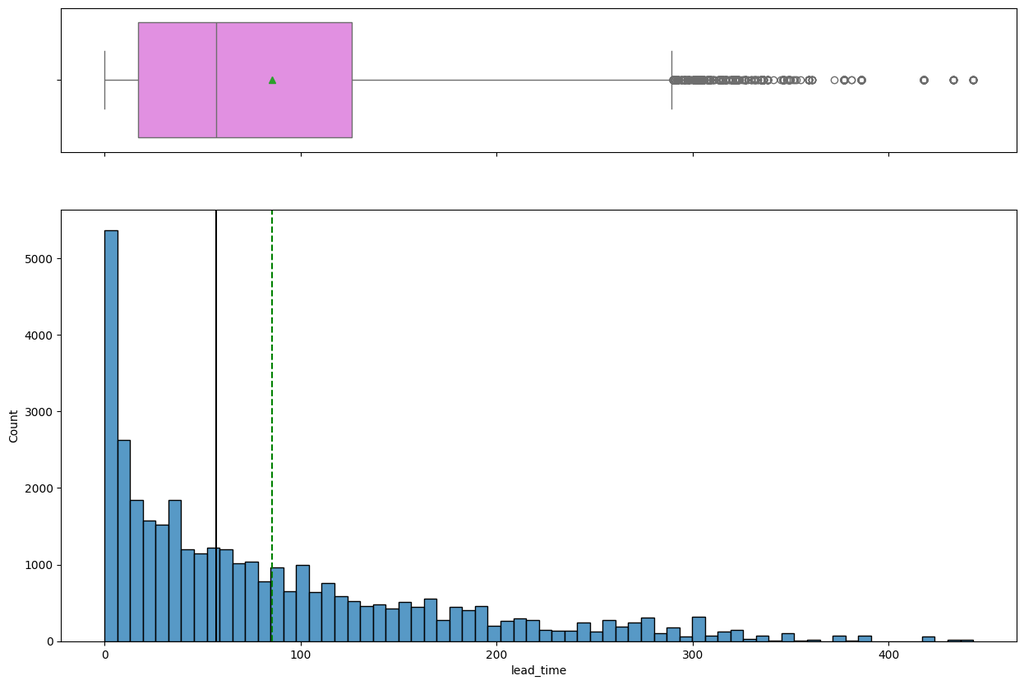

```python
histogram_boxplot(data, "lead_time")
```

#### From the histogram and boxplot for 'lead_time', we can make the following observations:

##### The histogram indicates that the distribution of lead_time is highly right-skewed. This means that a large proportion of bookings are made with relatively short lead times, while a smaller number of bookings are made far in advance. The long tail extending to the right of the histogram represents those few bookings that occur much earlier than the majority.

##### In terms of central tendency, the histogram shows that the mean (represented by the green dashed line) is positioned significantly to the right of the median (represented by the black solid line). This pattern is typical of a right-skewed distribution and suggests that the average lead time is influenced by a small number of very large values. As a result, the mean lead time appears higher because it is pulled upward by bookings made far in advance.

##### The boxplot further supports the presence of right-skewness and illustrates the spread of the data. Numerous individual points appear beyond the upper whisker of the boxplot, indicating the presence of outliers. These outliers represent bookings that were made significantly earlier than most of the other reservations in the dataset.

##### The minimum value of the lead time is shown to be 0, as indicated by the lower whisker of the boxplot. This confirms that some reservations are made on the same day as the arrival date.

##### Additionally, the majority of bookings fall within the interquartile range (IQR) shown in the boxplot. Based on the descriptive statistics, the 25th percentile occurs at approximately 17 days, while the 75th percentile occurs at approximately 126 days. This indicates that most bookings are made between 17 and 126 days before arrival, highlighting the typical planning window for the majority of customers.

## Observations on average price per room

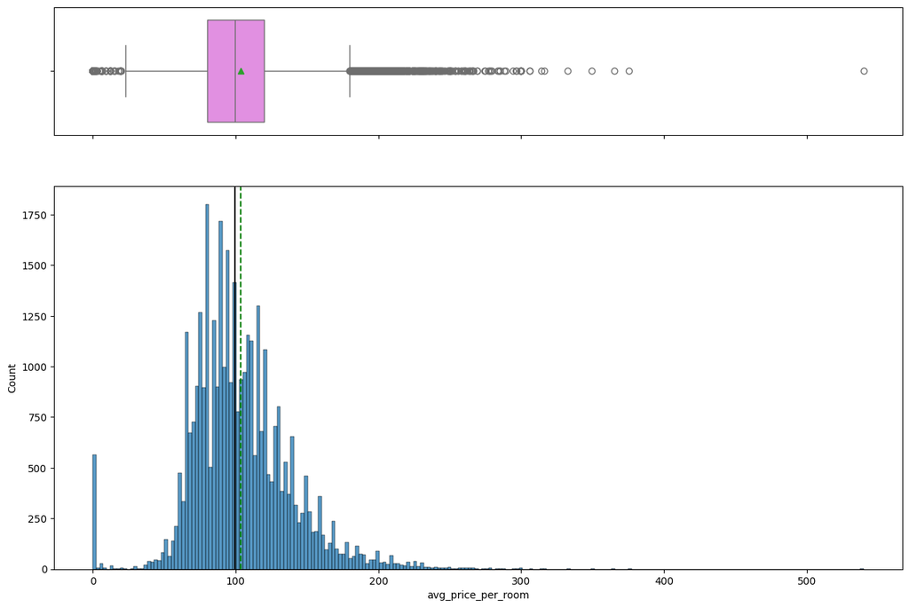

```python
# Complete code
histogram_boxplot(data, 'avg_price_per_room')
```

#### From the histogram and boxplot for 'avg_price_per_room', we can make the following observations:

##### The histogram illustrates that the distribution of average price per room (avg_price_per_room) is right-skewed. This indicates that the majority of bookings occur at relatively lower price levels, while a smaller number of bookings are made at much higher price points.

##### Regarding central tendency, the mean (represented by the green dashed line) is positioned to the right of the median (represented by the black solid line). This confirms the presence of right-skewness in the distribution. The higher mean value suggests that a few expensive bookings are influencing the average price, pulling it upward.

##### The boxplot reveals a minimum value of 0 for avg_price_per_room. This is considered an anomaly, as hotel rooms are typically not offered at no cost. Such entries may represent promotional stays, complimentary bookings, data entry errors, or special booking arrangements. These cases may require further investigation and potential data cleaning to ensure the accuracy of the analysis.

##### Additionally, the boxplot shows several outliers, represented by individual points beyond the upper whisker. These outliers indicate bookings with significantly higher average prices than the majority. This suggests that the dataset includes a wide range of room prices, possibly reflecting premium rooms, luxury accommodations, or special packages.

##### Finally, the interquartile range (IQR) displayed in the boxplot shows that the majority of the data is concentrated within a specific price range. However, the extended tail in the histogram and the presence of multiple outliers highlight considerable variability in room pricing within the dataset.

```python
data[data["avg_price_per_room"] == 0]
```

|  | no_of_adults | no_of_children | no_of_weekend_nights | no_of_week_nights | type_of_meal_plan | required_car_parking_space | room_type_reserved | lead_time | arrival_year | arrival_month | arrival_date | market_segment_type | repeated_guest | no_of_previous_cancellations | no_of_previous_bookings_not_canceled | avg_price_per_room | no_of_special_requests | booking_status |
| --- | --- | --- | --- | --- | --- | --- | --- | --- | --- | --- | --- | --- | --- | --- | --- | --- | --- | --- |
| 63 | 1 | 0 | 0 | 1 | Meal Plan 1 | 0 | Room_Type 1 | 2 | 2017 | 9 | 10 | Complementary | 0 | 0 | 0 | 0.00000 | 1 | Not_Canceled |
| 145 | 1 | 0 | 0 | 2 | Meal Plan 1 | 0 | Room_Type 1 | 13 | 2018 | 6 | 1 | Complementary | 1 | 3 | 5 | 0.00000 | 1 | Not_Canceled |
| 209 | 1 | 0 | 0 | 0 | Meal Plan 1 | 0 | Room_Type 1 | 4 | 2018 | 2 | 27 | Complementary | 0 | 0 | 0 | 0.00000 | 1 | Not_Canceled |
| 266 | 1 | 0 | 0 | 2 | Meal Plan 1 | 0 | Room_Type 1 | 1 | 2017 | 8 | 12 | Complementary | 1 | 0 | 1 | 0.00000 | 1 | Not_Canceled |
| 267 | 1 | 0 | 2 | 1 | Meal Plan 1 | 0 | Room_Type 1 | 4 | 2017 | 8 | 23 | Complementary | 0 | 0 | 0 | 0.00000 | 1 | Not_Canceled |
| ... | ... | ... | ... | ... | ... | ... | ... | ... | ... | ... | ... | ... | ... | ... | ... | ... | ... | ... |
| 35983 | 1 | 0 | 0 | 1 | Meal Plan 1 | 0 | Room_Type 7 | 0 | 2018 | 6 | 7 | Complementary | 1 | 4 | 17 | 0.00000 | 1 | Not_Canceled |
| 36080 | 1 | 0 | 1 | 1 | Meal Plan 1 | 0 | Room_Type 7 | 0 | 2018 | 3 | 21 | Complementary | 1 | 3 | 15 | 0.00000 | 1 | Not_Canceled |
| 36114 | 1 | 0 | 0 | 1 | Meal Plan 1 | 0 | Room_Type 1 | 1 | 2018 | 3 | 2 | Online | 0 | 0 | 0 | 0.00000 | 0 | Not_Canceled |
| 36217 | 2 | 0 | 2 | 1 | Meal Plan 1 | 0 | Room_Type 2 | 3 | 2017 | 8 | 9 | Online | 0 | 0 | 0 | 0.00000 | 2 | Not_Canceled |
| 36250 | 1 | 0 | 0 | 2 | Meal Plan 2 | 0 | Room_Type 1 | 6 | 2017 | 12 | 10 | Online | 0 | 0 | 0 | 0.00000 | 0 | Not_Canceled |

545 rows × 18 columns

#### By examining the bookings where the avg_price_per_room is 0, the observations that were made is that :

##### With respect to car parking, none of the bookings required a car parking space.

##### Looking at room type allocation, Room_Type 1 appears most frequently among these reservations, although other room types such as Room_Type 7 and Room_Type 2 are also present.

##### The lead time for these bookings varies significantly. Some reservations are made on the same day (lead_time = 0), while others are booked well in advance.

##### Finally, the analysis of previous guest activity shows that some guests are identified as repeat guests with a history of previous cancellations or non-canceled bookings, while others are new customers. This implies that zero-priced stays are not exclusively reserved for new guests or for those with problematic booking histories.

```python
data.loc[data["avg_price_per_room"] == 0, "market_segment_type"].value_counts()
```

```
market_segment_type
Complementary    354
Online           191
Name: count, dtype: int64
```

#### From the value_counts() output for market_segment_type, where the average price per room is 0, we can make the following observations:

##### A significant majority of the bookings with an average price of 0 belong to the 'Complementary' market segment (354 bookings). This strongly suggests that these are free stays provided by the hotel, possibly for staff, promotional events, or loyalty programs.

##### Also, a substantial number of zero-priced bookings also originate from the 'Online' market segment (191 bookings). This could indicate specific online promotions, package deals where the room price is bundled and effectively zero, or even potential data entry issues within online booking channels.

##### In total, there are 545 bookings (354 + 191) where the average price per room is recorded as 0.

```python
# Calculating the 25th quantile
Q1 = data["avg_price_per_room"].quantile(0.25)

# Calculating the 75th quantile
Q3 = data["avg_price_per_room"].quantile(0.75)

# Calculating IQR
IQR = Q3 - Q1

# Calculating value of upper whisker
Upper_Whisker = Q3 + 1.5 * IQR
Upper_Whisker
```

```
np.float64(179.55)
```

##### The calculated upper whisker value for avg_price_per_room is 179.55. In a boxplot, this value represents the upper threshold beyond which observations are classified as outliers. Therefore, any booking with an avg_price_per_room greater than 179.55 is considered an outlier and is displayed as an individual point beyond the upper whisker in the boxplot.

```python
# assigning the outliers the value of upper whisker
data.loc[data["avg_price_per_room"] >= 500, "avg_price_per_room"] = Upper_Whisker
```

## Observations on number of previous booking cancellations

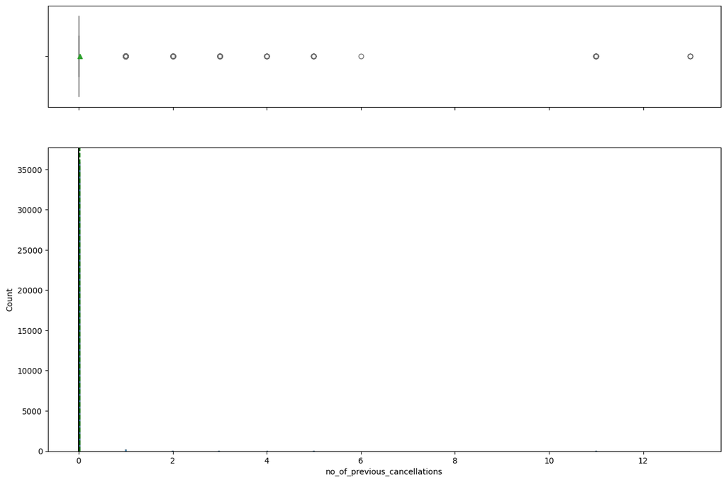

```python
# Complete code
histogram_boxplot(data, 'no_of_previous_cancellations')
```

#### From the histogram and boxplot for 'no_of_previous_cancellations', we can observe that:

##### The distribution is extremely right-skewed. The vast majority of bookings have 0 previous cancellations.

##### Also, both the mean and median are very close to 0, indicating that most guests do not have any previous cancellations.

##### Furthermore, the boxplot shows numerous individual data points far beyond the upper whisker, representing a small number of guests with a significantly high number of previous cancellations. While the exact count of these extreme outliers isn't visible on the plot, their presence suggests that a very small segment of guests has a history of repeated cancellations.

##### We can observe that the bulk of the data, as shown by the histogram and the boxplot, is concentrated at 0 previous cancellations.

## Observations on the number of previous bookings not canceled

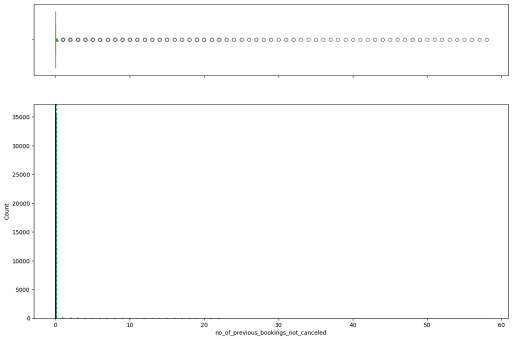

```python
# Complete code
histogram_boxplot(data, 'no_of_previous_bookings_not_canceled')
```

#### From the histogram and boxplot for 'no_of_previous_bookings_not_canceled', we can observe that:

##### The distribution is extremely right-skewed, with the vast majority of bookings having 0 previous non-canceled bookings.

##### Also, both the mean and median are very close to 0, indicating that most guests do not have any previous bookings that were not canceled.

##### The boxplot clearly shows numerous individual data points far beyond the upper whisker. These outliers represent a small segment of guests who have a significantly high number of previous bookings that were not canceled, suggesting they are repeat customers.

##### Majority of the data, as seen in both the histogram and boxplot, is concentrated at 0, indicating that for most bookings, there's no history of previous successful stays recorded under this metric.

```python
# function to create labeled barplots


def labeled_barplot(data, feature, perc=False, n=None):
    """
    Barplot with percentage at the top

    data: dataframe
    feature: dataframe column
    perc: whether to display percentages instead of count (default is False)
    n: displays the top n category levels (default is None, i.e., display all levels)
    """

    total = len(data[feature])  # length of the column
    count = data[feature].nunique()
    if n is None:
        plt.figure(figsize=(count + 2, 6))
    else:
        plt.figure(figsize=(n + 2, 6))

    plt.xticks(rotation=90, fontsize=15)
    ax = sns.countplot(
        data=data,
        x=feature,
        order=data[feature].value_counts().index[:n],
    )

    for p in ax.patches:
        if perc == True:
            label = "{:.1f}%".format(
                100 * p.get_height() / total
            )  # percentage of each class of the category
        else:
            label = p.get_height()  # count of each level of the category

        x = p.get_x() + p.get_width() / 2  # width of the plot
        y = p.get_height()  # height of the plot

        ax.annotate(
            label,
            (x, y),
            ha="center",
            va="center",
            size=12,
            xytext=(0, 5),
            textcoords="offset points",
        )  # annotate the percentage

    plt.show()  # show the plot
```

## Observations on number of adults

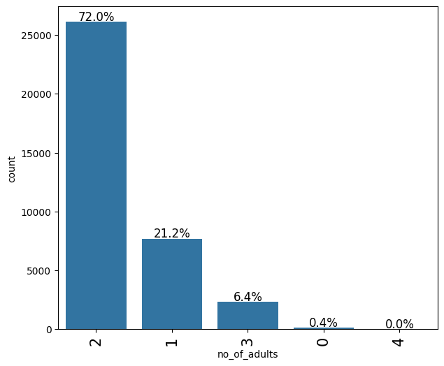

```python
labeled_barplot(data, "no_of_adults", perc=True)
```

## Observations on number of children

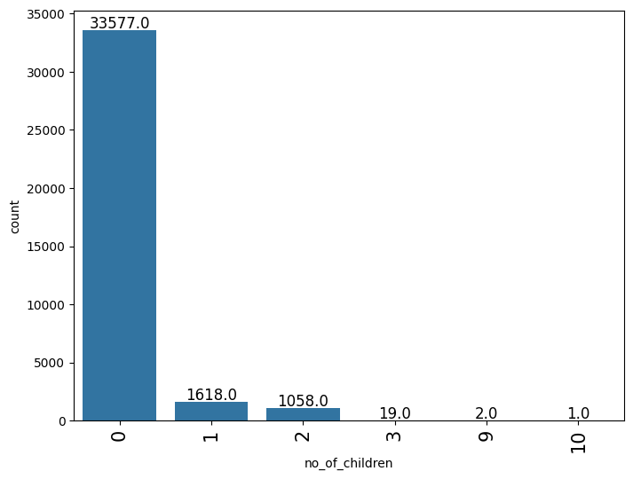

```python
# Complete code
labeled_barplot(data, 'no_of_children')
```

#### From the barplot for 'no_of_children', we can observe that:

##### The overwhelming majority of bookings, approximately 93.0%, are made with no children. (making reference to the describe().T, we will notice that the output has a 75th percentile of 0 for no_of_children). This indicates that most hotel guests do not bring children.

##### Bookings with 1 or 2 children make up a small portion of the dataset.

##### Also, bookings with 3 or more children are extremely rare.

```python
# replacing 9, and 10 children with 3
data["no_of_children"] = data["no_of_children"].replace([9, 10], 3)
```

## Observations on number of week nights

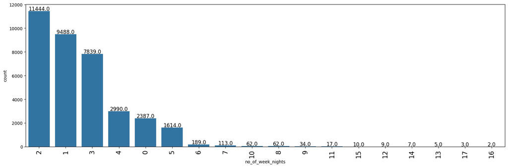

```python
# Complete code
labeled_barplot(data, 'no_of_week_nights')
```

#### From the barplot for 'no_of_week_nights', we can observe that:

##### 1, 2, and 3 week nights are the most frequent, with 2 week nights being the single most common duration.

##### large proportion of bookings are for relatively short week-night stays (1 to 4 nights).

## Observations on number of weekend nights

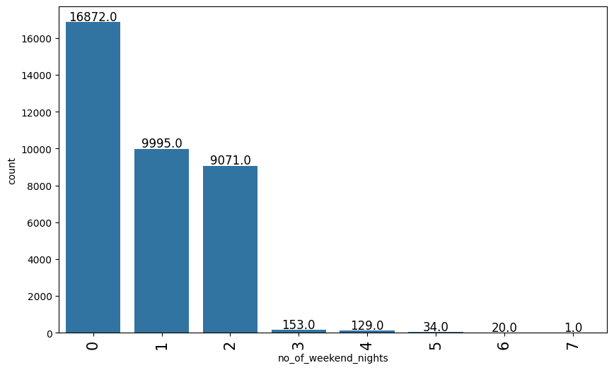

```python
# Complete code
labeled_barplot(data, 'no_of_weekend_nights')
```

#### From the barplot for 'no_of_weekend_nights', we can observe that:

##### Bookings with 0 weekend nights are the most frequent, followed closely by bookings with 1 and 2 weekend nights. The vast majority of bookings made up of 0, 1, or 2 weekend nights indicate that most hotel stays do not involve extended weekend periods.

##### Bookings for 3, 4, 5, 6, and 7 weekend nights are rare, representing a very small portion of the total bookings. The maximum observed is 7 weekend nights, but these are outliers.

## Observations on required car parking space

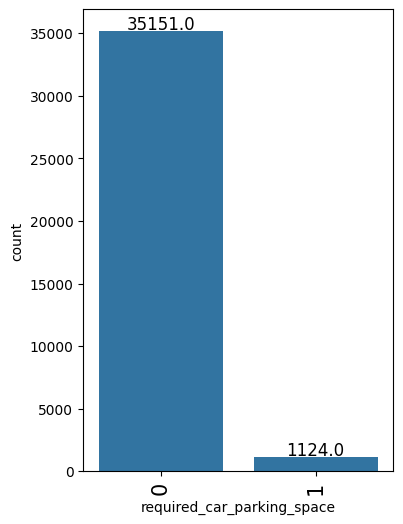

```python
# Complete code
labeled_barplot(data, 'required_car_parking_space')
```

#### From the barplot for 'required_car_parking_space', we can observe that:

##### The barplot clearly shows that the vast majority of bookings do not require a car parking space. The count for '0' (no parking required) is significantly higher than for '1' (parking required). Only a very small fraction of bookings request a car parking space, which indicates that car parking is a less common requirement among hotel guests in this dataset.

## Observations on type of meal plan

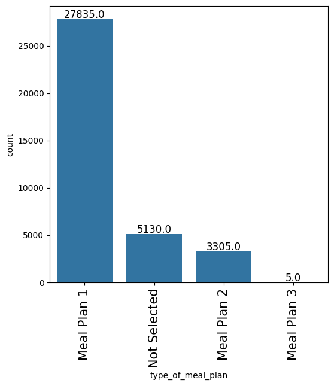

```python
# Complete code
labeled_barplot(data, 'type_of_meal_plan')
```

#### From the barplot for 'type_of_meal_plan', we can observe that :

##### 'Meal Plan 1' is by far the most popular choice, accounting for the vast majority of bookings, with 'Not Selected' being the second most common category, indicating a significant number of guests prefer to book rooms without a pre-selected meal plan, or perhaps these are room-only bookings.

##### 'Meal Plan 2' and 'Meal Plan 3' are considerably less frequent than 'Meal Plan 1' or 'Not Selected', suggesting they are niche options or offered less often.

## Observations on room type reserved

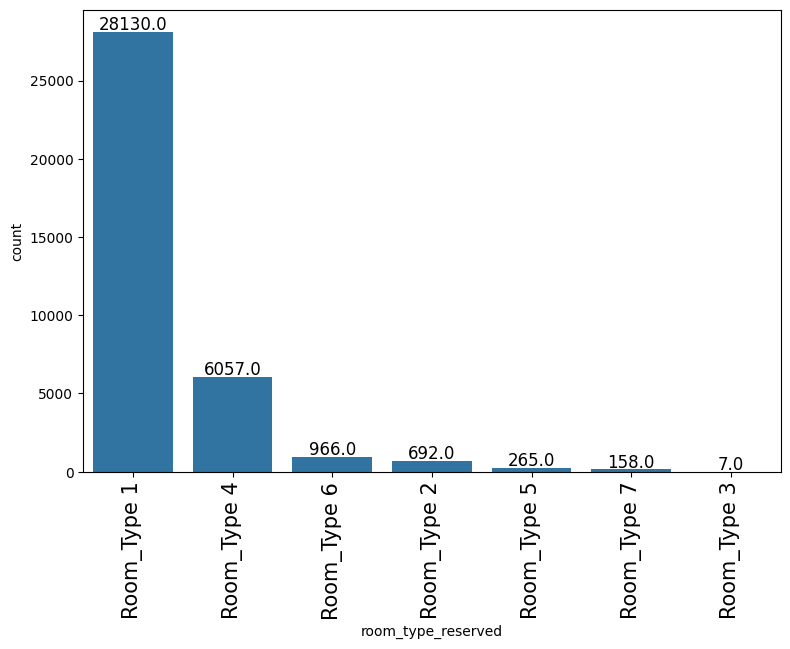

```python
# Complete code
labeled_barplot(data, 'room_type_reserved')
```

#### From the barplot for 'room_type_reserved', we can observe that:

##### Room_Type 1' is by far the most frequently reserved room type, accounting for a significant majority of bookings. This suggests it might be the standard or most widely available room category. Followed by 'Room_Type 4' and 'Room_Type 6', which are the next most common room types, though their counts are substantially lower than 'Room_Type 1'.

##### Also 'Room_Type 2', 'Room_Type 5', 'Room_Type 3', and 'Room_Type 7' are reserved much less often. This could be due to fewer available rooms in these categories, higher prices, or specific features that appeal to a smaller segment of guests.

## Observations on arrival month

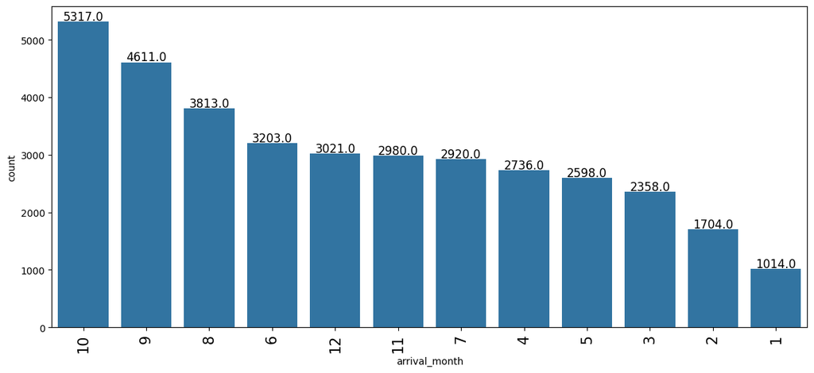

```python
# Complete code
labeled_barplot(data, 'arrival_month')
```

#### From the barplot for 'arrival_month', we can observe that:

##### Months like October, September, and August show significantly higher numbers of arrivals. These months appear to be particularly popular for hotel bookings.

##### Months such as June, July, and November and December also have a considerable number of arrivals, indicating a consistent demand during these periods.

##### January, February, and March tend to have fewer arrivals, suggesting these are relatively off-peak months. December shows a moderate number of arrivals.

## Observations on market segment type

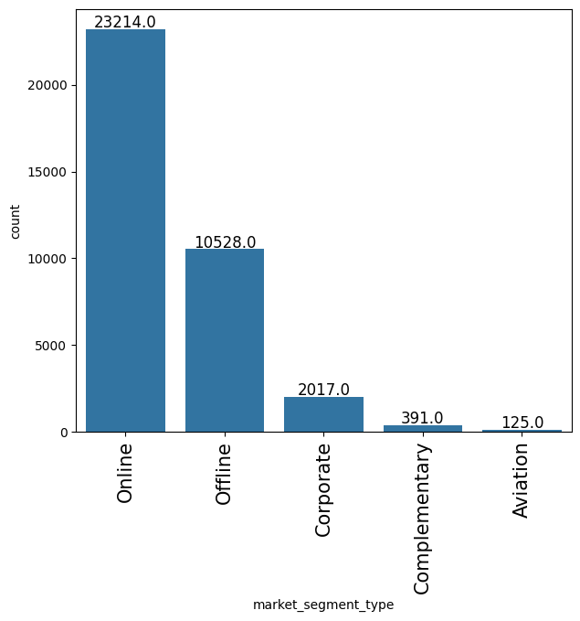

```python
# Complete code
labeled_barplot(data, 'market_segment_type')
```

#### From the barplot for 'market_segment_type', we can observe that:

##### The 'Online' market segment is the most common, accounting for a substantial portion of all bookings. This indicates that a majority of hotel reservations come through online channels.

##### 'Offline' bookings and 'Corporate' bookings are the next most common categories, though they are significantly less frequent than 'Online' bookings.

##### 'Complementary' bookings and 'Aviation' bookings make up a smaller portion of the market. 'Aviation' appears to be the least common market segment.

## Observations on number of special requests

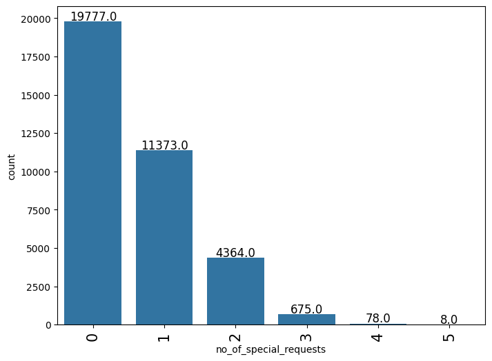

```python
# Complete code
labeled_barplot(data, 'no_of_special_requests')
```

#### From the barplot for 'no_of_special_requests', we can observe that:

##### The majority of bookings (approximately 54.5%) have no special requests, indicating that for most guests, standard accommodations are sufficient.

##### Bookings with one special request are the next most common, accounting for a significant portion (around 31.4%).

##### The number of bookings decreases sharply as the number of special requests increases. Bookings with 2 special requests are considerably less frequent than those with 1.

##### Bookings with 3, 4, or 5 special requests are very rare, which suggests that guests seldom have a high number of unique needs or preferences.

## Observations on booking status

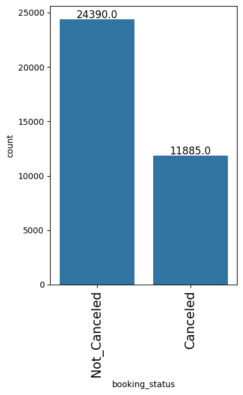

```python
# Complete code
labeled_barplot(data, 'booking_status')
```

#### From the barplot for 'booking_status', we can observe that:

##### The majority of bookings, approximately 67.3%, are 'Not_Canceled'. This indicates that most reservations proceed as planned and are fulfilled.

##### A substantial portion of bookings, about 32.7%, are 'Canceled'. This is a notable cancellation rate that could impact hotel revenue and operations.

## Let's encode Canceled bookings to 1 and Not_Canceled as 0 for further analysis

```python
data["booking_status"] = data["booking_status"].apply(
    lambda x: 1 if x == "Canceled" else 0
)
```

## Bivariate Analysis

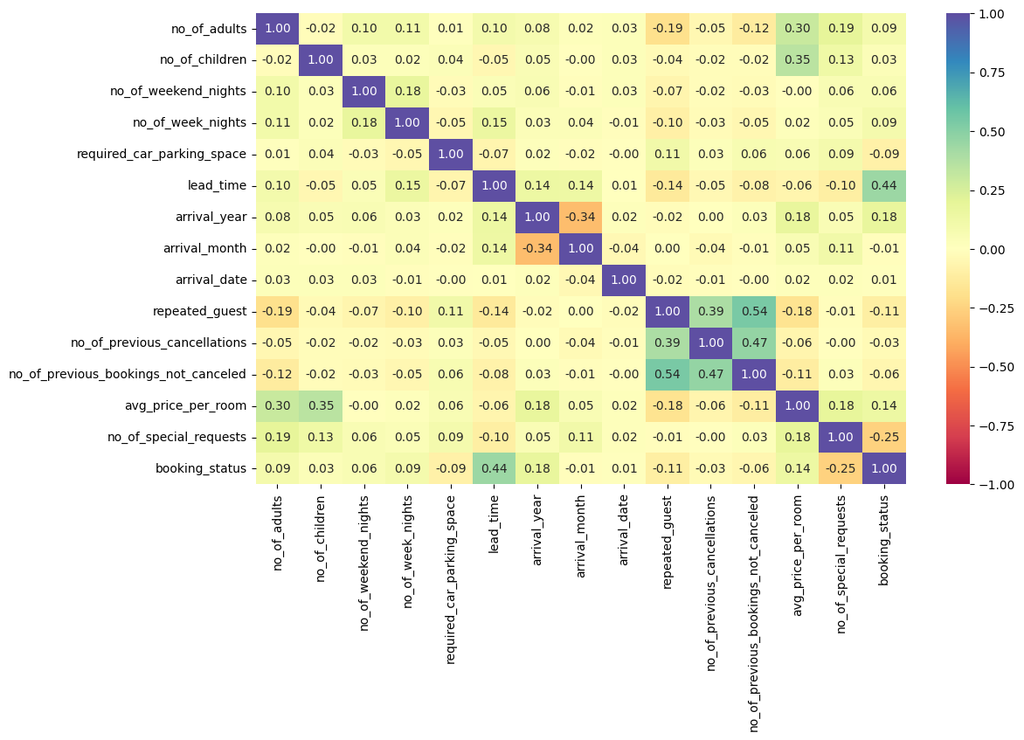

```python
cols_list = data.select_dtypes(include=np.number).columns.tolist()

plt.figure(figsize=(12, 7))
sns.heatmap(
    data[cols_list].corr(), annot=True, vmin=-1, vmax=1, fmt=".2f", cmap="Spectral"
)
plt.show()
```

#### From the heatmap showing the correlation matrix of the numerical features, we can observe that :

##### no_of_previous_bookings_not_canceled and repeated_guest have a strong positive correlation. This can be said to be logical, as repeated guests are more likely to have a history of non-canceled bookings.

##### no_of_week_nights and no_of_weekend_nights generally show a weak positive correlation.

##### There doesn't appear to be any extremely high correlation (e.g., >0.8 or < 0.8) among independent variables that would immediately suggest severe multicollinearity issues, but this would need a more detailed check if specific modeling techniques are employed.

### We now want to Create functions that will help us with further analysis.

```python
### function to plot distributions wrt target


def distribution_plot_wrt_target(data, predictor, target):

    fig, axs = plt.subplots(2, 2, figsize=(12, 10))

    target_uniq = data[target].unique()

    axs[0, 0].set_title("Distribution of target for target=" + str(target_uniq[0]))
    sns.histplot(
        data=data[data[target] == target_uniq[0]],
        x=predictor,
        kde=True,
        ax=axs[0, 0],
        color="teal",
        stat="density",
    )

    axs[0, 1].set_title("Distribution of target for target=" + str(target_uniq[1]))
    sns.histplot(
        data=data[data[target] == target_uniq[1]],
        x=predictor,
        kde=True,
        ax=axs[0, 1],
        color="orange",
        stat="density",
    )

    axs[1, 0].set_title("Boxplot w.r.t target")
    sns.boxplot(data=data, x=target, y=predictor, ax=axs[1, 0])

    axs[1, 1].set_title("Boxplot (without outliers) w.r.t target")
    sns.boxplot(
        data=data,
        x=target,
        y=predictor,
        ax=axs[1, 1],
        showfliers=False,
    )

    plt.tight_layout()
    plt.show()
```

```python
def stacked_barplot(data, predictor, target):
    """
    Print the category counts and plot a stacked bar chart

    data: dataframe
    predictor: independent variable
    target: target variable
    """
    count = data[predictor].nunique()
    sorter = data[target].value_counts().index[-1]
    tab1 = pd.crosstab(data[predictor], data[target], margins=True).sort_values(
        by=sorter, ascending=False
    )
    print(tab1)
    print("-" * 120)
    tab = pd.crosstab(data[predictor], data[target], normalize="index").sort_values(
        by=sorter, ascending=False
    )
    tab.plot(kind="bar", stacked=True, figsize=(count + 5, 5))
    plt.legend(
        loc="lower left", frameon=False,
    )
    plt.legend(loc="upper left", bbox_to_anchor=(1, 1))
    plt.show()
```

### Hotel rates are dynamic and change according to demand and customer demographics. Let's see how prices vary across different market segments

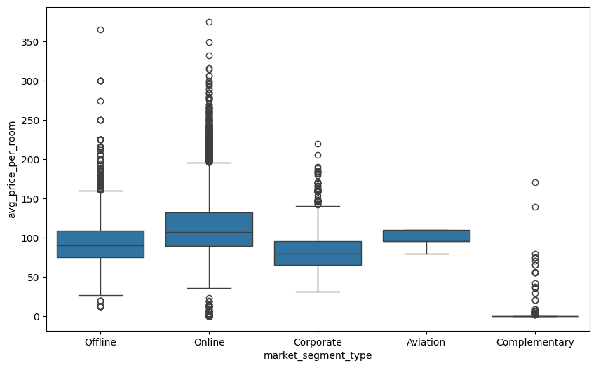

```python
plt.figure(figsize=(10, 6))
sns.boxplot(
    data=data, x="market_segment_type", y="avg_price_per_room"
)
plt.show()
```

### Let's see how booking status varies across different market segments. Also, how average price per room impacts booking status

```
booking_status           0      1    All
market_segment_type
All                  24390  11885  36275
Online               14739   8475  23214
Offline               7375   3153  10528
Corporate             1797    220   2017
Aviation                88     37    125
Complementary          391      0    391
------------------------------------------------------------------------------------------------------------------------
```

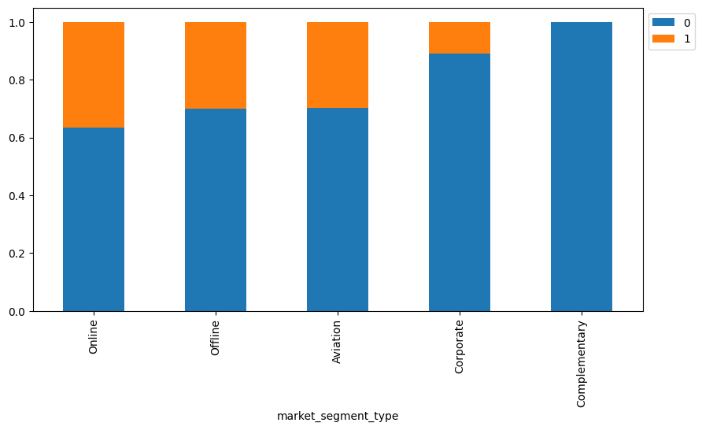

```python
stacked_barplot(data, "market_segment_type", "booking_status")
```

#### From the stacked barplot and the crosstabulation table showing 'market_segment_type' versus 'booking_status', we can observe that:

##### The 'Online' market segment not only accounts for the largest share of total bookings (23,214) but also has the highest absolute number of cancellations (8,475), with a cancellation rate of approximately 36.51%.

##### The 'Offline' segment is the second-largest in terms of bookings (10,528) and cancellations (3,153), showing a cancellation rate of about 29.95%.

##### The 'Aviation' segment, despite being small in total bookings (125), exhibits a relatively high cancellation rate of 29.6% (37 out of 125 bookings).

##### The 'Corporate' segment has a significantly lower cancellation rate of approximately 10.9% (220 out of 2,017 bookings), suggesting corporate clients are more reliable once a booking is made.

##### the 'Complementary' market segment shows no cancellations (0 out of 391 bookings). This reinforces the idea that these are likely special, non-revenue-generating bookings (e.g., staff, promotions) that are less likely to be canceled.

### Many guests have special requirements when booking a hotel room. Let's see how it impacts cancellations

```
booking_status              0      1    All
no_of_special_requests
All                     24390  11885  36275
0                       11232   8545  19777
1                        8670   2703  11373
2                        3727    637   4364
3                         675      0    675
4                          78      0     78
5                           8      0      8
------------------------------------------------------------------------------------------------------------------------
```

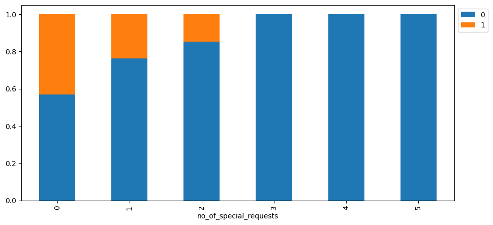

```python
# Complete code
stacked_barplot(data, 'no_of_special_requests', 'booking_status')
```

#### From the stacked barplot and the crosstabulation table showing 'no_of_special_requests' versus 'booking_status', we can observe that:

##### There is a clear inverse relationship between the number of special requests and the likelihood of cancellation. As the number of special requests increases, the cancellation rate significantly decreases.

##### Bookings with 0 special requests have the highest cancellation rate. Specifically, out of 19,777 bookings with no special requests, 8,545 were canceled, resulting in a cancellation rate of approximately 43.2%.

###### There is a decrease in cancellations with more requests. Hence, for bookings with 1 special request, the cancellation rate drops to about 23.7% (2,703 canceled out of 11,373 total). For bookings with 2 special requests, the cancellation rate further decreases to approximately 14.6% (637 canceled out of 4,364 total).

##### Remarkably, bookings with 3, 4, or 5 special requests show a 0% cancellation rate. This strongly suggests that guests who take the effort to make multiple special requests are highly committed to their reservations and are very unlikely to cancel.

### Let's see if the special requests made by the customers impacts the prices of a room

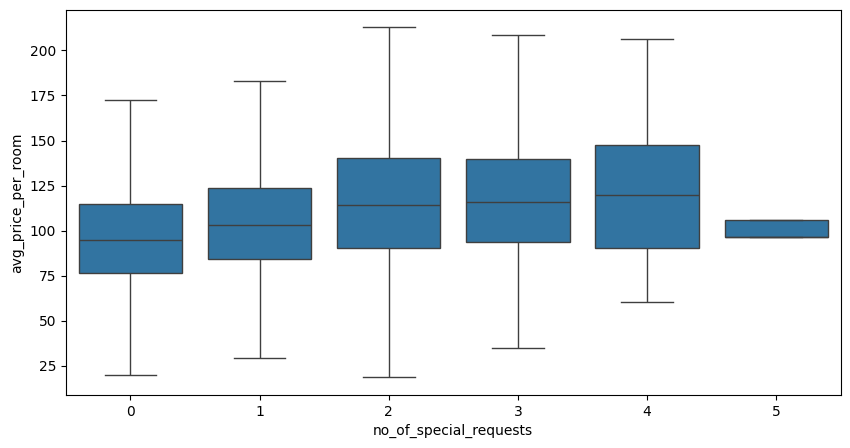

```python
plt.figure(figsize=(10, 5))
# Complete code to create boxplot for no of special requests and average price per room (excluding outliers)
sns.boxplot(data=data, x='no_of_special_requests', y='avg_price_per_room', showfliers=False)
plt.show()
```

#### From the boxplot visualizing 'no_of_special_requests' against 'avg_price_per_room' (with outliers hidden to show the main distribution more clearly), we can observe that :

##### There appears to be a slight general trend where bookings with more special requests tend to have a slightly higher median average price per room. This suggests that guests making special requests might be booking slightly more expensive rooms or that special requests are more common with higher-end bookings.

##### The median average prices for 0, 1, and 2 special requests seem to be similar, although there's a minor upward trend.

##### Bookings with 3 and 4 special requests show slightly higher median prices compared to those with fewer requests. This could indicate that guests with more specific needs are either willing to pay more or are booking room types that inherently have a higher average price.

### We saw earlier that there is a positive correlation between booking status and average price per room. Let's analyze it

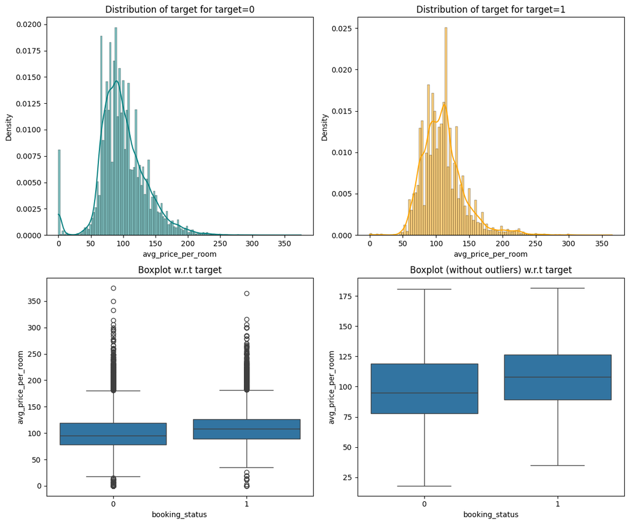

```python
distribution_plot_wrt_target(data, "avg_price_per_room", "booking_status")
```

### There is a positive correlation between booking status and lead time also. Let's analyze it further

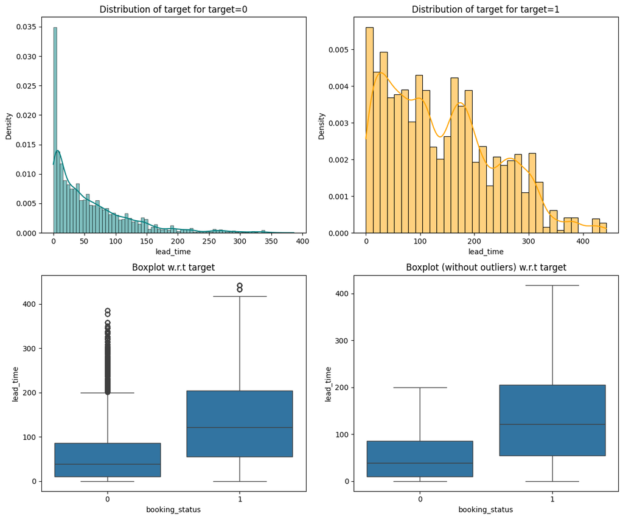

```python
# Complete code
distribution_plot_wrt_target(data, 'lead_time', 'booking_status')
```

#### From the distribution plot comparing 'lead_time' with 'booking_status', we can observe that:

###### In relation to the distribution for Not-Canceled Bookings (0): The histogram for 'Not_Canceled' bookings shows a distribution concentrated at shorter lead times, with a peak closer to 0-50 days. The distribution is right-skewed, indicating that many successful bookings are made closer to the arrival date.

##### The boxplot confirms a lower median lead time and a narrower spread for 'Not_Canceled' bookings compared to 'Canceled' ones, especially when outliers are excluded (showfliers=False).

##### In relation to the distribution for Canceled Bookings (1): The histogram for 'Canceled' bookings appears to be shifted towards longer lead times compared to 'Not_Canceled' bookings. It also exhibits a broader spread, with a more pronounced tail towards very long lead times.

##### The boxplot for 'Canceled' bookings shows a significantly higher median lead time and a broader interquartile range. This visually supports the positive correlation seen in the heatmap, suggesting that bookings made further in advance are more likely to be canceled.

##### In comparison, both distributions are right-skewed, but the 'Canceled' bookings consistently show higher lead times. This implies that customers who book well in advance have a greater propensity to cancel their reservations, possibly due to finding better deals, or less commitment when booking far ahead.

### Generally people travel with their spouse and children for vacations or other activities. Let's create a new dataframe of the customers who traveled with their families and analyze the impact on booking status.

```python
family_data = data[(data["no_of_children"] >= 0) & (data["no_of_adults"] > 1)]
family_data.shape
```

```
(28441, 18)
```

```python
family_data["no_of_family_members"] = (
    family_data["no_of_adults"] + family_data["no_of_children"]
)
```

```python
# Creating the missing column by summing adults and children
data['no_of_family_members'] = data['no_of_adults'] + data['no_of_children']
```

```python
print(data.columns)
```

```
Index(['no_of_adults', 'no_of_children', 'no_of_weekend_nights',
       'no_of_week_nights', 'type_of_meal_plan', 'required_car_parking_space',
       'room_type_reserved', 'lead_time', 'arrival_year', 'arrival_month',
       'arrival_date', 'market_segment_type', 'repeated_guest',
       'no_of_previous_cancellations', 'no_of_previous_bookings_not_canceled',
       'avg_price_per_room', 'no_of_special_requests', 'booking_status',
       'no_of_family_members'],
      dtype='object')
```

```
booking_status            0      1    All
no_of_family_members
All                   24390  11885  36275
2                     15662   8280  23942
1                      5743   1809   7552
3                      2459   1392   3851
4                       515    398    913
5                        11      6     17
------------------------------------------------------------------------------------------------------------------------
```

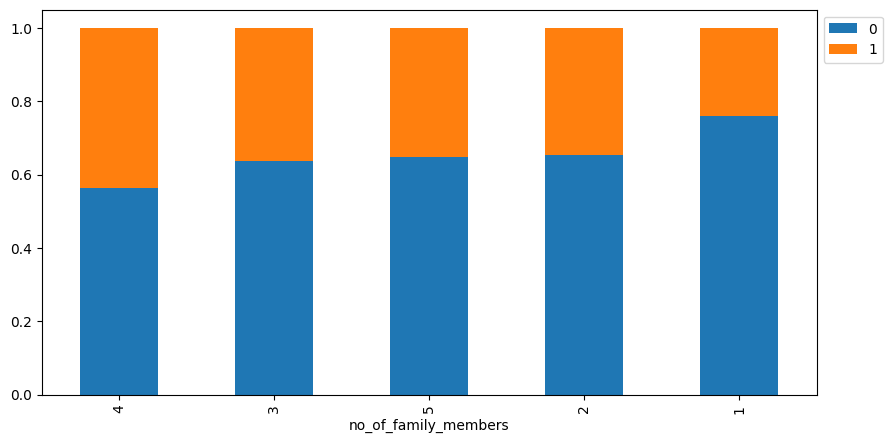

```python
# Complete code
stacked_barplot(data, 'no_of_family_members', 'booking_status')
```

#### From the stacked barplot and the crosstabulation table showing 'no_of_family_members' versus 'booking_status', we can observe that :

##### Bookings with 2 family members (likely couples) account for the largest proportion of total bookings (23,942), followed by bookings with 1 family member (7,552).

##### Out of 23,942 bookings with 2 family members, 8,280 were canceled, resulting in a cancellation rate of approximately 34.58%.

##### For bookings with 1 family member, 1,809 out of 7,552 were canceled, leading to a cancellation rate of approximately 23.95%.

##### With 3 family members, 1,392 out of 3,851 bookings were canceled, yielding a cancellation rate of approximately 36.15%.

##### Bookings with 4 family members show 398 cancellations out of 913, which is a cancellation rate of approximately 43.59%.

##### For bookings with 5 family members, 6 out of 17 were canceled, resulting in a cancellation rate of approximately 35.29%.

##### There appears to be a notable increase in cancellation rates as the number of family members increases, peaking at 4 family members. Bookings for 4 family members have the highest cancellation rate among all observed categories. Bookings with 1 family member have a significantly lower cancellation rate compared to groups of 2 or more.

### Let's do a similar analysis for the customer who stay for at least a day at the hotel.

```python
stay_data = data[(data["no_of_week_nights"] > 0) & (data["no_of_weekend_nights"] > 0)]
stay_data.shape
```

```
(17094, 19)
```

```python
stay_data["total_days"] = (
    stay_data["no_of_week_nights"] + stay_data["no_of_weekend_nights"]
)
```

```
booking_status      0     1    All
total_days
All             10979  6115  17094
3                3689  2183   5872
4                2977  1387   4364
5                1593   738   2331
2                1301   639   1940
6                 566   465   1031
7                 590   383    973
8                 100    79    179
10                 51    58    109
9                  58    53    111
14                  5    27     32
15                  5    26     31
13                  3    15     18
12                  9    15     24
11                 24    15     39
20                  3     8     11
19                  1     5      6
16                  1     5      6
17                  1     4      5
18                  0     3      3
21                  1     3      4
22                  0     2      2
23                  1     1      2
24                  0     1      1
------------------------------------------------------------------------------------------------------------------------
```

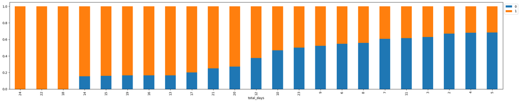

```python
# Complete code
stacked_barplot(stay_data, 'total_days', 'booking_status')
```

#### From the stacked barplot and the crosstabulation table showing 'total_days' versus 'booking_status', we can observe that:

##### Most common stay durations are found with 3, 4, and 5 total days, followed by 2 days. These account for the bulk of the bookings in this subset, where both weekend and week nights are present.

##### Cancellation Rate for Shorter Stays (2-5 days):

##### days: ~32.94% (639 canceled out of 1940)

##### 3 days: ~37.18% (2183 canceled out of 5872)

##### 4 days: ~31.78% (1387 canceled out of 4364)

##### 5 days: ~31.66% (738 canceled out of 2331). These rates are relatively consistent, around one-third of bookings being canceled.

##### Increase in Cancellation for Medium-Long Stays (6-10 days):

##### 6 days: ~45.10% (465 canceled out of 1031)

##### 7 days: ~39.36% (383 canceled out of 973)

##### 8 days: ~44.13% (79 canceled out of 179)

##### 9 days: ~47.75% (53 canceled out of 111)

##### 10 days: ~53.21% (58 canceled out of 109). There is a clear upward trend in cancellation rates as the stay duration extends into the medium-long range.

##### Very High Cancellation for Longer Stays (12+ days):

##### For stays of 12 days and more (e.g., 12, 13, 14, 15, 16, 17, 18, 19, 20, 21, 22, 23, 24), the cancellation rates become exceptionally high, often exceeding 70% and even reaching 100% for very rare instances (e.g., 18, 22, 24 days).

##### There is a strong positive correlation between the length of stay and the likelihood of cancellation, especially for stays exceeding 5 days. Longer duration bookings appear to carry a significantly higher risk of cancellation. This could be due to more complex logistics, higher total costs, or simply more opportunities for plans to change over extended periods.

### Repeating guests are the guests who stay in the hotel often and are important to brand equity. Let's see what percentage of repeating guests cancel?

```
booking_status      0      1    All
repeated_guest
All             24390  11885  36275
0               23476  11869  35345
1                 914     16    930
------------------------------------------------------------------------------------------------------------------------
```

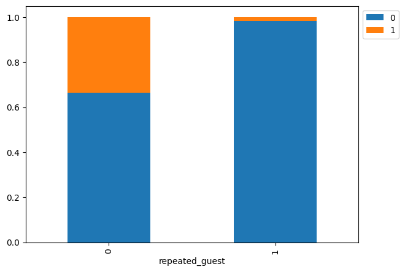

```python
# Complete code
stacked_barplot(data, 'repeated_guest', 'booking_status')
```

#### From the stacked barplot and the crosstabulation table showing 'repeated_guest' versus 'booking_status', we can observe that:

##### The vast majority of bookings are made by non-repeated guests (35,345 bookings, accounting for roughly 97.4% of the total).

##### For repeated guests (those with repeated_guest = 1), only 16 out of 930 bookings were canceled. This translates to an extremely low cancellation rate of approximately 1.72%.

##### on the other hand, non-repeated guests (those with repeated_guest = 0) have a significantly higher cancellation rate. Out of 35,345 bookings, 11,869 were canceled, resulting in a cancellation rate of approximately 33.58%.

##### This data strongly suggests that repeated guests are far more reliable and have a much lower probability to cancel their bookings compared to first-time guests. Their commitment to their reservations is significantly higher.

### Let's find out what are the busiest months in the hotel.

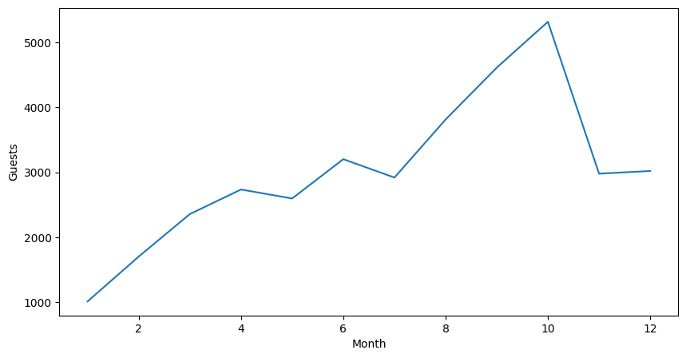

```python
# grouping the data on arrival months and extracting the count of bookings
monthly_data = data.groupby(["arrival_month"])["booking_status"].count()

# creating a dataframe with months and count of customers in each month
monthly_data = pd.DataFrame(
    {"Month": list(monthly_data.index), "Guests": list(monthly_data.values)}
)

# plotting the trend over different months
plt.figure(figsize=(10, 5))
sns.lineplot(data=monthly_data, x="Month", y="Guests")
plt.show()
```

### Let's check the percentage of bookings canceled in each month.

```
booking_status      0      1    All
arrival_month
All             24390  11885  36275
10               3437   1880   5317
9                3073   1538   4611
8                2325   1488   3813
7                1606   1314   2920
6                1912   1291   3203
4                1741    995   2736
5                1650    948   2598
11               2105    875   2980
3                1658    700   2358
2                1274    430   1704
12               2619    402   3021
1                 990     24   1014
------------------------------------------------------------------------------------------------------------------------
```

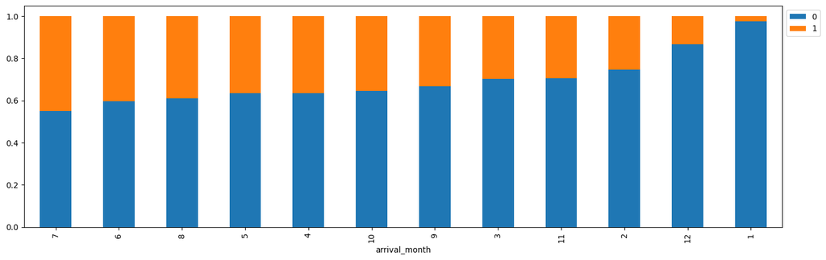

```python
# Complete code
stacked_barplot(data, 'arrival_month', 'booking_status')
```

#### From the stacked barplot and the crosstabulation table showing 'arrival_month' versus 'booking_status', we can observe that :

##### January (Month 1) stands out with an exceptionally low cancellation rate of approximately 2.37% (24 canceled out of 1014 total bookings). This suggests that bookings made for arrival in January are highly committed.

##### July (Month 7) exhibits the highest cancellation rate at approximately 45.00% (1314 canceled out of 2920 total bookings). This might indicate that during peak summer months, bookings are more fluid or speculative.

##### Cancellation rates generally trend upwards from February through to July. For example, February is around 25.23%, March is around 29.69%, April is around 36.36%, May is around 36.49%, and June is around 40.31%.

##### Rates remain high but fluctuate during late summer and autumn, with August at around 39.02%, September at around 33.35%, and October at around 35.36%.

##### Cancellation rates tend to decrease towards the end of the year, with November at approximately 29.36% and December at approximately 13.31%, though still significantly higher than January.

### As hotel room prices are dynamic, Let's see how the prices vary across different months

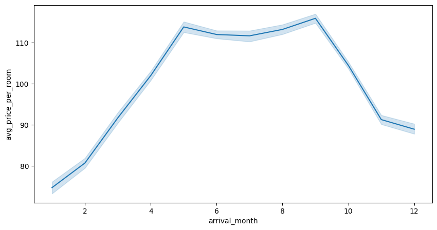

```python
plt.figure(figsize=(10, 5))
# Complete code to create lineplot between average price per room and arrival month
sns.lineplot(data=data, x='arrival_month', y='avg_price_per_room')
plt.show()
```

#### From the line plot visualizing 'arrival_month' against 'avg_price_per_room', we can observe that:

##### The average price per room tends to be higher during certain months, notably during the summer months (e.g., August and September). These periods likely correspond to high-demand travel seasons.

##### On the other hand, months like January, February, and March show lower average prices. This aligns with these being generally off-peak travel months, where hotels might offer lower rates to attract guests.

## Data Preprocessing

### Outlier Check

#### Let's check for outliers in the data.

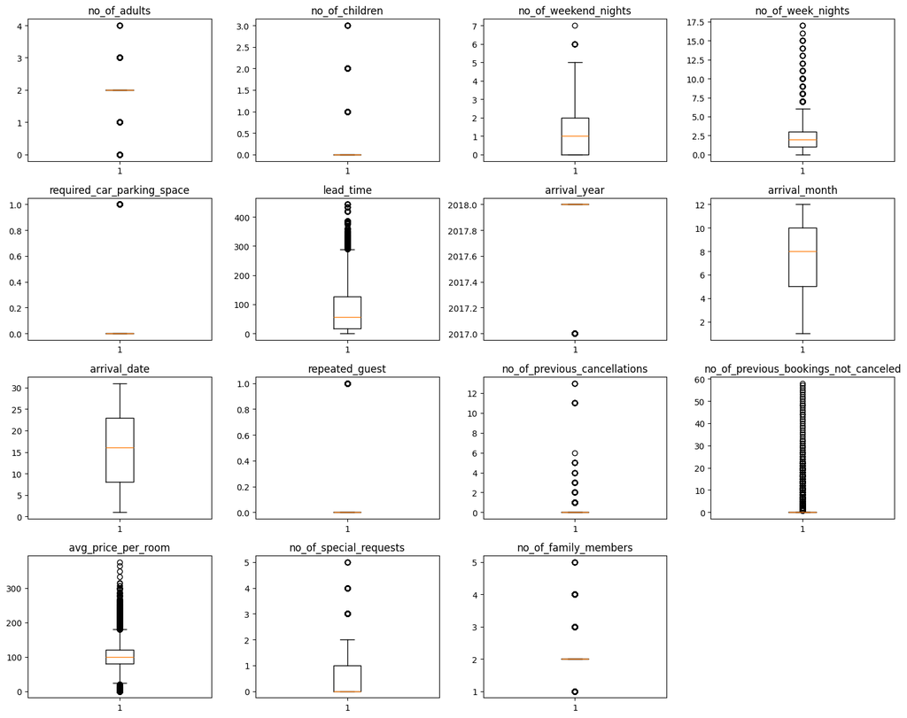

```python
# outlier detection using boxplot
numeric_columns = data.select_dtypes(include=np.number).columns.tolist()
# dropping booking_status
numeric_columns.remove("booking_status")

plt.figure(figsize=(15, 12))

for i, variable in enumerate(numeric_columns):
    plt.subplot(4, 4, i + 1)
    plt.boxplot(data[variable], whis=1.5)
    plt.tight_layout()
    plt.title(variable)

plt.show()
```

#### From the boxplots generated for the numerical columns, we can observe that :

##### Many of the numerical features exhibit a significant number of outliers, particularly on the upper side. This is visible as individual points extending far beyond the upper whiskers of the boxplots. Examples include lead_time, no_of_previous_cancellations, no_of_previous_bookings_not_canceled, and avg_price_per_room.

##### several features like lead_time, no_of_children, no_of_weekend_nights, no_of_week_nights, no_of_previous_cancellations, no_of_previous_bookings_not_canceled, and no_of_special_requests show strong right-skewness. This is indicated by the median being closer to the bottom of the box and long upper whiskers with many outliers.

## Model Building

### Model evaluation criterion

#### Model can make wrong predictions as:

##### Predicting a customer will not cancel their booking, but in reality, the customer will cancel their booking.

##### Predicting a customer will cancel their booking, but in reality, the customer will not cancel their booking.

#### In terms of this, which case is more important?

#### Both cases are important as:

##### If we predict that a booking will not be canceled and the booking gets canceled, then the hotel will lose resources and will have to bear additional costs of distribution channels.

##### If we predict that a booking will get canceled and the booking doesn't get canceled, the hotel might not be able to provide satisfactory services to the customer by assuming that this booking will be canceled. This might damage the brand equity.

#### How can the losses be reduced?

##### Hotel would want the F1 Score to be maximized, greater the F1 score higher the chances of minimizing False Negatives and False Positives.

### First, let's create functions to calculate different metrics and confusion matrix so that we don't have to use the same code repeatedly for each model.

#### The model_performance_classification_statsmodels function will be used to check the model performance of models.

#### The confusion_matrix_statsmodels function will be used to plot the confusion matrix.

```python
# defining a function to compute different metrics to check performance of a classification model built using statsmodels
def model_performance_classification_statsmodels(
    model, predictors, target, threshold=0.5
):
    """
    Function to compute different metrics to check classification model performance

    model: classifier
    predictors: independent variables
    target: dependent variable
    threshold: threshold for classifying the observation as class 1
    """

    # checking which probabilities are greater than threshold
    pred_temp = model.predict(predictors) > threshold
    # rounding off the above values to get classes
    pred = np.round(pred_temp)

    acc = accuracy_score(target, pred)  # to compute Accuracy
    recall = recall_score(target, pred)  # to compute Recall
    precision = precision_score(target, pred)  # to compute Precision
    f1 = f1_score(target, pred)  # to compute F1-score

    # creating a dataframe of metrics
    df_perf = pd.DataFrame(
        {"Accuracy": acc, "Recall": recall, "Precision": precision, "F1": f1,},
        index=[0],
    )

    return df_perf
```

```python
# defining a function to plot the confusion_matrix of a classification model


def confusion_matrix_statsmodels(model, predictors, target, threshold=0.5):
    """
    To plot the confusion_matrix with percentages

    model: classifier
    predictors: independent variables
    target: dependent variable
    threshold: threshold for classifying the observation as class 1
    """
    y_pred = model.predict(predictors) > threshold
    cm = confusion_matrix(target, y_pred)
    labels = np.asarray(
        [
            ["{0:0.0f}".format(item) + "\n{0:.2%}".format(item / cm.flatten().sum())]
            for item in cm.flatten()
        ]
    ).reshape(2, 2)

    plt.figure(figsize=(6, 4))
    sns.heatmap(cm, annot=labels, fmt="")
    plt.ylabel("True label")
    plt.xlabel("Predicted label")
```

### Logistic Regression (with statsmodels library)

### Data Preparation for modeling (Logistic Regression)

#### We want to predict which bookings will be canceled.

#### Before we proceed to build a model, we'll have to encode categorical features.

#### We'll split the data into train and test to be able to evaluate the model that we build on the train data.

```python
X = data.drop(["booking_status"], axis=1)
Y = data["booking_status"]

# adding constant (statsmodels requires an explicit intercept)
X = sm.add_constant(X)

# creating dummy variables for categorical features
X = pd.get_dummies(X, drop_first=True)

# Splitting data in train and test sets in the ratio 70:30
X_train, X_test, y_train, y_test = train_test_split(X, Y, test_size=0.30, random_state=1)
```

```python
print("Shape of Training set : ", X_train.shape)
print("Shape of test set : ", X_test.shape)
print("Percentage of classes in training set:")
print(y_train.value_counts(normalize=True))
print("Percentage of classes in test set:")
print(y_test.value_counts(normalize=True))
```

```
Shape of Training set :  (25392, 29)
Shape of test set :  (10883, 29)
Percentage of classes in training set:
booking_status
0   0.67064
1   0.32936
Name: proportion, dtype: float64
Percentage of classes in test set:
booking_status
0   0.67638
1   0.32362
Name: proportion, dtype: float64
```

#### From the output showing the shapes and class distributions of your training and test sets, we can observe that :

##### The dataset has been successfully split into training and test sets. The training set (X_train, y_train) contains 25,392 samples, while the test set (X_test, y_test) contains 10,883 samples. This roughly corresponds to a 70:30 split, as intended.

##### In the training set, approximately 67.1% of bookings are 'Not_Canceled' (0) and 32.9% are 'Canceled' (1).

##### Similarly, in the test set, about 67.6% are 'Not_Canceled' (0) and 32.4% are 'Canceled' (1).

### Building Logistic Regression Model

```python
# fitting logistic regression model
logit = sm.Logit(y_train, X_train.astype(float))
lg = logit.fit() ## Complete the code to fit logistic regression

print(lg.summary()) ## Complete the code to print summary of the model
```

```
Warning: Maximum number of iterations has been exceeded.
         Current function value: 0.425090
         Iterations: 35
                           Logit Regression Results
==============================================================================
Dep. Variable:         booking_status   No. Observations:                25392
Model:                          Logit   Df Residuals:                    25363
Method:                           MLE   Df Model:                           28
Date:                Sat, 14 Mar 2026   Pseudo R-squ.:                  0.3292
Time:                        02:10:46   Log-Likelihood:                -10794.
converged:                      False   LL-Null:                       -16091.
Covariance Type:            nonrobust   LLR p-value:                     0.000
========================================================================================================
                                           coef    std err          z      P>|z|      [0.025      0.975]
--------------------------------------------------------------------------------------------------------
const                                 -922.8266    120.832     -7.637      0.000   -1159.653    -686.000
no_of_adults                             0.0232        nan        nan        nan         nan         nan
no_of_children                           0.0675        nan        nan        nan         nan         nan
no_of_weekend_nights                     0.1067      0.020      5.395      0.000       0.068       0.145
no_of_week_nights                        0.0397      0.012      3.235      0.001       0.016       0.064
required_car_parking_space              -1.5943      0.138    -11.565      0.000      -1.865      -1.324
lead_time                                0.0157      0.000     58.863      0.000       0.015       0.016
arrival_year                             0.4561      0.060      7.617      0.000       0.339       0.573
arrival_month                           -0.0417      0.006     -6.441      0.000      -0.054      -0.029
arrival_date                             0.0005      0.002      0.259      0.796      -0.003       0.004
repeated_guest                          -2.3472      0.617     -3.806      0.000      -3.556      -1.139
no_of_previous_cancellations             0.2664      0.086      3.108      0.002       0.098       0.434
no_of_previous_bookings_not_canceled    -0.1727      0.153     -1.131      0.258      -0.472       0.127
avg_price_per_room                       0.0188      0.001     25.396      0.000       0.017       0.020
no_of_special_requests                  -1.4689      0.030    -48.782      0.000      -1.528      -1.410
no_of_family_members                     0.0905        nan        nan        nan         nan         nan
type_of_meal_plan_Meal Plan 2            0.1756      0.067      2.636      0.008       0.045       0.306
type_of_meal_plan_Meal Plan 3           17.3584   3987.835      0.004      0.997   -7798.655    7833.372
type_of_meal_plan_Not Selected           0.2784      0.053      5.247      0.000       0.174       0.382
room_type_reserved_Room_Type 2          -0.3605      0.131     -2.748      0.006      -0.618      -0.103
room_type_reserved_Room_Type 3          -0.0012      1.310     -0.001      0.999      -2.568       2.566
room_type_reserved_Room_Type 4          -0.2823      0.053     -5.304      0.000      -0.387      -0.178
room_type_reserved_Room_Type 5          -0.7189      0.209     -3.438      0.001      -1.129      -0.309
room_type_reserved_Room_Type 6          -0.9501      0.151     -6.274      0.000      -1.247      -0.653
room_type_reserved_Room_Type 7          -1.4003      0.294     -4.770      0.000      -1.976      -0.825
market_segment_type_Complementary      -40.5975   5.65e+05  -7.19e-05      1.000   -1.11e+06    1.11e+06
market_segment_type_Corporate           -1.1924      0.266     -4.483      0.000      -1.714      -0.671
market_segment_type_Offline             -2.1946      0.255     -8.621      0.000      -2.694      -1.696
market_segment_type_Online              -0.3995      0.251     -1.590      0.112      -0.892       0.093
========================================================================================================
```

#### From the logistic regression model summary, we can observe that :

##### Variables like type_of_meal_plan_Meal Plan 3 and market_segment_type_Complementary have extremely large standard errors and insignificant p-values, making their coefficients highly unstable and unreliable. This typically occurs when a category has very few observations or leads to perfect separation.

##### no_of_weekend_nights, no_of_week_nights, lead_time, arrival_year, no_of_previous_cancellations, and avg_price_per_room, are associated with an increased likelihood of cancellation.

##### required_car_parking_space, arrival_month (indicating certain months have lower cancellation rates), repeated_guest, no_of_special_requests, and several room type/market segment dummies (e.g., room_type_reserved_Room_Type 2, market_segment_type_Corporate, market_segment_type_Online) are associated with a decreased likelihood of cancellation.

```python
# Convert all columns to float to avoid the 'exp' attribute error
X_train = X_train.astype(float)
X_test = X_test.astype(float)

# Now try running your performance function again
model_performance_classification_statsmodels(lg, X_train, y_train)
```

|  | Accuracy | Recall | Precision | F1 |
| --- | --- | --- | --- | --- |
| 0 | 0.80600 | 0.63410 | 0.73971 | 0.68285 |

#### From the model performance on the training set, we can make the following analysis:

##### The model achieved an accuracy of approximately 80.6%. This means that 80.6% of the predictions (both canceled and not-canceled bookings) were correct.

##### The recall for the positive class (Canceled bookings, represented by 1) is about 63.41%. This means that the model correctly identified 63.41% of all actual canceled bookings. A higher recall is important for minimizing False Negatives (i.e., predicting a booking will not be canceled when it actually will).

##### The precision for canceled bookings is about 73.97%. This indicates that when the model predicts a booking will be canceled, it is correct 73.97% of the time. High precision helps minimize False Positives (i.e., predicting a booking will be canceled when it actually won't).

##### F1-score: The F1-score is approximately 68.28%. The F1-score is a good overall indicator of the model's performance on the minority class.

##### The model shows decent performance on the training data, with a good balance between precision and recall for the 'Canceled' class, as reflected by the F1-score. These metrics are on the training data, so it's essential to evaluate performance on the test set and address the model's underlying problems for a reliable real-world application.

## Multicollinearity

```python
# we will define a function to check VIF
def checking_vif(predictors):
    vif = pd.DataFrame()
    vif["feature"] = predictors.columns

    # calculating VIF for each feature
    vif["VIF"] = [
        variance_inflation_factor(predictors.values, i)
        for i in range(len(predictors.columns))
    ]
    return vif
```

```python
checking_vif(X_train)
```

|  | feature | VIF |
| --- | --- | --- |
| 0 | const | 39497686.20788 |
| 1 | no_of_adults | inf |
| 2 | no_of_children | inf |
| 3 | no_of_weekend_nights | 1.06948 |
| 4 | no_of_week_nights | 1.09571 |
| 5 | required_car_parking_space | 1.03997 |
| 6 | lead_time | 1.39517 |
| 7 | arrival_year | 1.43190 |
| 8 | arrival_month | 1.27633 |
| 9 | arrival_date | 1.00679 |
| 10 | repeated_guest | 1.78358 |
| 11 | no_of_previous_cancellations | 1.39569 |
| 12 | no_of_previous_bookings_not_canceled | 1.65200 |
| 13 | avg_price_per_room | 2.06860 |
| 14 | no_of_special_requests | 1.24798 |
| 15 | no_of_family_members | inf |
| 16 | type_of_meal_plan_Meal Plan 2 | 1.27328 |
| 17 | type_of_meal_plan_Meal Plan 3 | 1.02526 |
| 18 | type_of_meal_plan_Not Selected | 1.27306 |
| 19 | room_type_reserved_Room_Type 2 | 1.10595 |
| 20 | room_type_reserved_Room_Type 3 | 1.00330 |
| 21 | room_type_reserved_Room_Type 4 | 1.36361 |
| 22 | room_type_reserved_Room_Type 5 | 1.02800 |
| 23 | room_type_reserved_Room_Type 6 | 2.05614 |
| 24 | room_type_reserved_Room_Type 7 | 1.11816 |
| 25 | market_segment_type_Complementary | 4.50276 |
| 26 | market_segment_type_Corporate | 16.92829 |
| 27 | market_segment_type_Offline | 64.11564 |
| 28 | market_segment_type_Online | 71.18026 |

## Dropping high p-value variables

### We will drop the predictor variables having a p-value greater than 0.05 as they do not significantly impact the target variable.

### But sometimes p-values change after dropping a variable. So, we'll not drop all variables at once.

### Instead, we will do the following:

#### Build a model, check the p-values of the variables, and drop the column with the highest p-value.

#### Create a new model without the dropped feature, check the p-values of the variables, and drop the column with the highest p-value.

#### Repeat the above two steps till there are no columns with p-value > 0.05.

```python
# initial list of columns
cols = X_train.columns.tolist()

# setting an initial max p-value
max_p_value = 1

while len(cols) > 0:
    # defining the train set
    x_train_aux = X_train[cols]

    # fitting the model
    model = sm.Logit(y_train, x_train_aux).fit(disp=False)

    # getting the p-values and the maximum p-value
    p_values = model.pvalues
    max_p_value = max(p_values)

    # name of the variable with maximum p-value
    feature_with_p_max = p_values.idxmax()

    if max_p_value > 0.05:
        cols.remove(feature_with_p_max)
    else:
        break

selected_features = cols
print(selected_features)
```

[output not shown]

```python
X_train1 = X_train[selected_features]
X_test1 = X_test[selected_features]
```

```python
# Train the model on the optimized feature set
logit1 = sm.Logit(y_train, X_train1)

# Fit the model
lg1 = logit1.fit()

# Print the summary to see the final coefficients and p-values
print(lg1.summary())
```

```
Optimization terminated successfully.
         Current function value: 0.425739
         Iterations 11
                           Logit Regression Results
==============================================================================
Dep. Variable:         booking_status   No. Observations:                25392
Model:                          Logit   Df Residuals:                    25371
Method:                           MLE   Df Model:                           20
Date:                Sat, 14 Mar 2026   Pseudo R-squ.:                  0.3282
Time:                        02:11:40   Log-Likelihood:                -10810.
converged:                       True   LL-Null:                       -16091.
Covariance Type:            nonrobust   LLR p-value:                     0.000
==================================================================================================
                                     coef    std err          z      P>|z|      [0.025      0.975]
--------------------------------------------------------------------------------------------------
const                           -919.1159    120.346     -7.637      0.000   -1154.989    -683.243
no_of_weekend_nights               0.1084      0.020      5.491      0.000       0.070       0.147
no_of_week_nights                  0.0418      0.012      3.406      0.001       0.018       0.066
required_car_parking_space        -1.5961      0.138    -11.576      0.000      -1.866      -1.326
lead_time                          0.0157      0.000     59.248      0.000       0.015       0.016
arrival_year                       0.4540      0.060      7.613      0.000       0.337       0.571
arrival_month                     -0.0424      0.006     -6.582      0.000      -0.055      -0.030
repeated_guest                    -2.7342      0.556     -4.915      0.000      -3.825      -1.644
no_of_previous_cancellations       0.2285      0.077      2.979      0.003       0.078       0.379
avg_price_per_room                 0.0192      0.001     26.367      0.000       0.018       0.021
no_of_special_requests            -1.4699      0.030    -48.887      0.000      -1.529      -1.411
no_of_family_members               0.1192      0.034      3.532      0.000       0.053       0.185
type_of_meal_plan_Meal Plan 2      0.1636      0.067      2.459      0.014       0.033       0.294
type_of_meal_plan_Not Selected     0.2824      0.053      5.368      0.000       0.179       0.386
room_type_reserved_Room_Type 2    -0.3345      0.127     -2.630      0.009      -0.584      -0.085
room_type_reserved_Room_Type 4    -0.2896      0.052     -5.563      0.000      -0.392      -0.188
room_type_reserved_Room_Type 5    -0.7333      0.208     -3.522      0.000      -1.141      -0.325
room_type_reserved_Room_Type 6    -0.9157      0.128     -7.165      0.000      -1.166      -0.665
room_type_reserved_Room_Type 7    -1.4107      0.290     -4.859      0.000      -1.980      -0.842
market_segment_type_Corporate     -0.7891      0.103     -7.674      0.000      -0.991      -0.588
market_segment_type_Offline       -1.7866      0.052    -34.408      0.000      -1.888      -1.685
==================================================================================================
```

#### From the summary of the refined Logistic Regression model (lg1), we can observe that :

##### This is a significant improvement after removing highly correlated and insignificant variables.

##### All remaining predictors in selected_features are statistically significant (p-values are less than 0.05), which means they have a statistically significant impact on the booking_status.

##### no_of_weekend_nights, no_of_week_nights, lead_time, arrival_year, no_of_previous_cancellations, avg_price_per_room, no_of_family_members, type_of_meal_plan_Meal Plan 2, and type_of_meal_plan_Not Selected are associated with an increased likelihood of cancellation.

##### required_car_parking_space, arrival_month, repeated_guest, no_of_special_requests, room_type_reserved_Room_Type 2, room_type_reserved_Room_Type 4, room_type_reserved_Room_Type 5, room_type_reserved_Room_Type 6, room_type_reserved_Room_Type 7, market_segment_type_Corporate, and market_segment_type_Offline are associated with a decreased likelihood of cancellation.

##### The removal of no_of_adults, no_of_children, type_of_meal_plan_Meal Plan 3, room_type_reserved_Room_Type 3, market_segment_type_Complementary, and market_segment_type_Online (due to high p-values or multicollinearity) has resulted in a more stable and interpretable model. The nan values are gone, and all coefficients have valid standard errors and p-values.

##### This refined model provides a clearer understanding of the factors influencing hotel booking cancellations.

```python
print("Training performance:")
# Complete the code to check performance on X_train1 and y_train
model_performance_classification_statsmodels(lg1, X_train1, y_train)
```

```
Training performance:
```

|  | Accuracy | Recall | Precision | F1 |
| --- | --- | --- | --- | --- |
| 0 | 0.80545 | 0.63279 | 0.73900 | 0.68178 |

#### From the training performance output for the refined logistic regression model, we can analyze that:

##### The model achieved an accuracy of approximately 80.55%. This means that roughly 80.55% of the predictions (both canceled and not-canceled bookings) were correct on the training set.

##### The recall for the positive class (Canceled bookings, represented by 1) is about 63.28%. This indicates that the model correctly identified 63.28% of all actual canceled bookings in the training data. This metric is important for minimizing false negatives (bookings that are predicted not to cancel but actually do).

##### The precision for canceled bookings is about 73.90%. This means that when the model predicts a booking will be canceled, it is correct 73.90% of the time. High precision helps minimize false positives (bookings predicted to cancel but which do not).

##### The F1-score is approximately 68.18%. This metric provides a balanced measure of the model's precision and recall for the 'Canceled' class. An F1-score of around 68% indicates a reasonably good balance in performance on the minority class.

##### The model demonstrates consistent performance on the training data compared to the initial model (before feature selection). The metrics suggest a balanced predictive capability for identifying canceled bookings, which is crucial for the hotel's business strategy. However, it's essential to evaluate these metrics on the unseen test set to ensure the model generalizes well.

### Converting coefficients to odds

#### The coefficients of the logistic regression model are in terms of log(odd), to find the odds we have to take the exponential of the coefficients.

#### The percentage change in odds is given as odds = (exp(b) - 1) * 100

```python
# converting coefficients to odds
odds = np.exp(lg1.params)

# finding the percentage change
perc_change_odds = (np.exp(lg1.params) - 1) * 100

# removing limit from number of columns to display
pd.set_option("display.max_columns", None)

# adding the odds to a dataframe
pd.DataFrame({"Odds": odds, "Change_odd%": perc_change_odds}, index=X_train1.columns).T
```

|  | const | no_of_weekend_nights | no_of_week_nights | required_car_parking_space | lead_time | arrival_year | arrival_month | repeated_guest | no_of_previous_cancellations | avg_price_per_room | no_of_special_requests | no_of_family_members | type_of_meal_plan_Meal Plan 2 | type_of_meal_plan_Not Selected | room_type_reserved_Room_Type 2 | room_type_reserved_Room_Type 4 | room_type_reserved_Room_Type 5 | room_type_reserved_Room_Type 6 | room_type_reserved_Room_Type 7 | market_segment_type_Corporate | market_segment_type_Offline |
| --- | --- | --- | --- | --- | --- | --- | --- | --- | --- | --- | --- | --- | --- | --- | --- | --- | --- | --- | --- | --- | --- |
| Odds | 0.00000 | 1.11453 | 1.04268 | 0.20269 | 1.01583 | 1.57465 | 0.95845 | 0.06495 | 1.25666 | 1.01938 | 0.22994 | 1.12658 | 1.17770 | 1.32631 | 0.71567 | 0.74856 | 0.48034 | 0.40023 | 0.24397 | 0.45427 | 0.16753 |
| Change_odd% | -100.00000 | 11.45271 | 4.26817 | -79.73097 | 1.58251 | 57.46483 | -4.15546 | -93.50512 | 25.66628 | 1.93838 | -77.00616 | 12.65830 | 17.76974 | 32.63080 | -28.43285 | -25.14432 | -51.96621 | -59.97674 | -75.60258 | -54.57316 | -83.24690 |

#### From the calculated odds and percentage change in odds, we can make the following analysis for each predictor's impact on the likelihood of a booking being canceled, holding other variables constant:

##### Increased Likelihood of Cancellation (Positive Impact):

##### (arrival_year): For every one-unit increase in arrival year (e.g., from 2017 to 2018), the odds of cancellation increase by approximately 57.46%. This suggests that bookings in more recent years in this dataset had a higher tendency to cancel.

##### (no_of_previous_cancellations): A one-unit increase in previous cancellations increases the odds of current booking cancellation by approximately 25.67%. This confirms that guests with a history of cancellations are significantly more likely to cancel again.

##### (no_of_family_members): For each additional family member, the odds of cancellation increase by approximately 12.66%.

##### (no_of_weekend_nights): Each additional weekend night increases the odds of cancellation by about 11.45%.

##### (lead_time): For every one-unit increase in lead time (one more day in advance), the odds of cancellation increase by about 1.58%. This indicates that bookings made further in advance have a slightly higher chance of being canceled.

##### (avg_price_per_room): A one-unit increase in average price per room slightly increases the odds of cancellation by approximately 1.94%.

##### (no_of_week_nights): Each additional week night increases the odds of cancellation by about 4.27%.

##### 'Meal Plan 2': Compared to the baseline meal plan, opting for 'Meal Plan 2' increases the odds of cancellation by approximately 17.77%.

##### Meal Plan 'Not Selected': If a meal plan is 'Not Selected', the odds of cancellation increase by approximately 32.63% compared to the baseline meal plan.

##### Decreased Likelihood of Cancellation (Negative Impact):

##### (repeated_guest): Being a repeated guest drastically reduces the odds of cancellation by about 93.51%. This is a very strong indicator of guest commitment.

##### Market Segment 'Offline': Bookings made through the 'Offline' market segment significantly decrease the odds of cancellation by approximately 83.25% compared to the baseline. This indicates higher commitment from offline channels.

##### (no_of_special_requests): For each additional special request, the odds of cancellation decrease by approximately 77.01%. This highlights that guests with special requests are highly committed.

##### 'Room_Type 7': Reserving 'Room_Type 7' reduces the odds of cancellation by approximately 75.60% compared to the baseline room type.

##### 'Room_Type 6': Reserving 'Room_Type 6' reduces the odds of cancellation by approximately 59.98%.

##### Market Segment 'Corporate': Corporate bookings reduce the odds of cancellation by approximately 54.57%.

##### Room Type 'Room_Type 5': Reserving 'Room_Type 5' reduces the odds of cancellation by approximately 51.97%.

##### (required_car_parking_space): If a car parking space is required, the odds of cancellation decrease by approximately 79.73%.

##### Room Type 'Room_Type 4': Reserving 'Room_Type 4' reduces the odds of cancellation by approximately 25.14%.

##### Room Type 'Room_Type 2': Reserving 'Room_Type 2' reduces the odds of cancellation by approximately 28.43%.

##### Arrival Month (arrival_month): For every one-unit increase in arrival month (e.g., from January to February), the odds of cancellation decrease by about 4.16%.

### Checking model performance on the training set

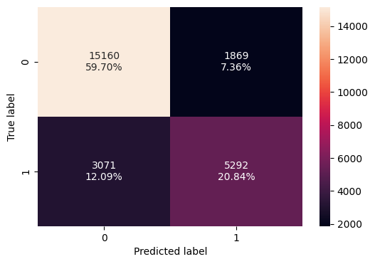

```python
# creating confusion matrix
confusion_matrix_statsmodels(lg1, X_train1, y_train)
```

```python
print("Training performance:")
# Complete the code to check performance on X_train1 and y_train
log_reg_model_train_perf = model_performance_classification_statsmodels(lg1, X_train1, y_train)
log_reg_model_train_perf
```

```
Training performance:
```

|  | Accuracy | Recall | Precision | F1 |
| --- | --- | --- | --- | --- |
| 0 | 0.80545 | 0.63279 | 0.73900 | 0.68178 |

#### From the training performance output for the refined logistic regression model, we can analyze that :

##### The model achieved an accuracy of approximately 80.55%. This means that roughly 80.55% of the predictions (both canceled and not-canceled bookings) were correct on the training set.

##### The model demonstrates consistent performance on the training data compared to the initial model (before feature selection). The metrics suggest a balanced predictive capability for identifying canceled bookings, which is crucial for the hotel's business strategy. However, it's essential to evaluate these metrics on the unseen test set to ensure the model generalizes well.

### ROC-AUC

#### ROC-AUC on training set

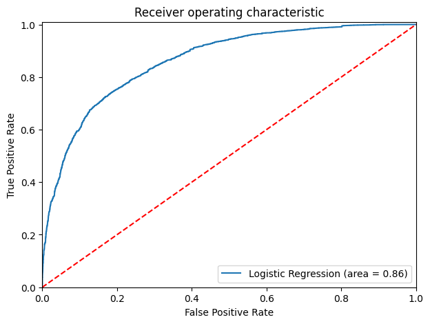

```python
logit_roc_auc_train = roc_auc_score(y_train, lg1.predict(X_train1))
fpr, tpr, thresholds = roc_curve(y_train, lg1.predict(X_train1))
plt.figure(figsize=(7, 5))
plt.plot(fpr, tpr, label="Logistic Regression (area = %0.2f)" % logit_roc_auc_train)
plt.plot([0, 1], [0, 1], "r--")
plt.xlim([0.0, 1.0])
plt.ylim([0.0, 1.01])
plt.xlabel("False Positive Rate")
plt.ylabel("True Positive Rate")
plt.title("Receiver operating characteristic")
plt.legend(loc="lower right")
plt.show()
```

#### From the ROC curve and AUC score on the training set, we can make the following analysis:

##### ROC-AUC Score: The calculated ROC-AUC score for the training set is approximately 0.86. This is a good score, indicating that the model has a strong ability to distinguish between canceled and not-canceled bookings.

##### This plot suggests that the logistic regression model, after feature selection, has good discriminative power. It is capable of effectively ranking positive cases higher than negative cases, which is crucial for identifying bookings at risk of cancellation.

### Model Performance Improvement

#### Let's see if the recall score can be improved further, by changing the model threshold using AUC-ROC Curve.

### Optimal threshold using AUC-ROC curve

```python
# Optimal threshold as per AUC-ROC curve
# The optimal cut off would be where tpr is high and fpr is low
fpr, tpr, thresholds = roc_curve(y_train, lg1.predict(X_train1))

optimal_idx = np.argmax(tpr - fpr)
optimal_threshold_auc_roc = thresholds[optimal_idx]
print(optimal_threshold_auc_roc)
```

```
0.3707001171994645
```

##### The optimal threshold determined from the ROC-AUC curve for your logistic regression model is approximately 0.3707.

##### Using this optimal threshold of 0.3707 instead of the default 0.5 can lead to an improved recall score for the 'Canceled' class, which is beneficial when minimizing false negatives is critical for business operations (e.g., preventing lost revenue from unmanaged cancellations). It means that at this threshold, we will catch a higher proportion of actual cancellations, even if it might slightly increase the number of times you incorrectly predict a non-cancellation as a cancellation.

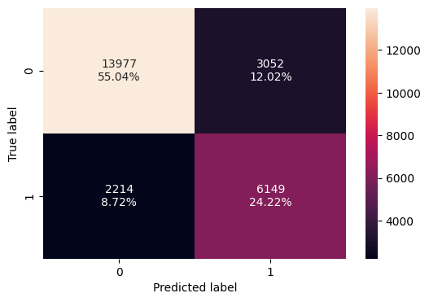

```python
# creating confusion matrix
confusion_matrix_statsmodels(
    lg1, X_train1, y_train, threshold=optimal_threshold_auc_roc
)
```

```python
# checking model performance for this model
log_reg_model_train_perf_threshold_auc_roc = model_performance_classification_statsmodels(
    lg1, X_train1, y_train, threshold=optimal_threshold_auc_roc
)
print("Training performance:")
log_reg_model_train_perf_threshold_auc_roc
```

```
Training performance:
```

|  | Accuracy | Recall | Precision | F1 |
| --- | --- | --- | --- | --- |
| 0 | 0.79261 | 0.73526 | 0.66830 | 0.70018 |

#### From the training performance output for the logistic regression model using the optimal threshold of approximately 0.37, we can analyze that:

##### The accuracy has slightly decreased from ~80.55% (with default threshold) to approximately 79.26%. This is expected, as optimizing for recall often involves a slight trade-off in overall accuracy.

##### The recall for the positive class (Canceled bookings) has significantly increased from ~63.28% to approximately 73.53%. This means the model is now much better at identifying actual canceled bookings, reducing False Negatives. This is a critical improvement for minimizing missed opportunities to intervene with at-risk bookings.

##### The precision for canceled bookings has decreased from ~73.90% to approximately 66.83%. This indicates that when the model predicts a booking will be canceled, it is correct a slightly lower percentage of the time. This implies an increase in False Positives (bookings predicted to cancel that actually don't).

##### The F1-score, which balances precision and recall, has slightly increased from ~68.18% to approximately 70.02%. This indicates that, for this problem, the optimal threshold has led to an overall better balance of precision and recall for the positive class, making it a more effective model for the hotel's objectives.

##### By lowering the classification threshold to 0.37, the model is now more aggressive in identifying potential cancellations. This strategic adjustment significantly improves the model's ability to 'catch' actual cancellations (higher recall) at the cost of a minor increase in false alarms (lower precision). Given that both types of errors have important business implications for the hotel, the increase in F1-score suggests that this adjusted model provides a more desirable performance profile, allowing the hotel to proactively manage a greater number of at-risk bookings.